[figure not shown]

Search the manual

# ReaClassical Table of Contents

## Welcome

Introduction

What's New in ReaClassical 27

Documentation

Website

Coming from Standard REAPER

Donations

Other Ways to Contribute

Spread the Word

Compatibility

Source Code

Development Style

Versioning Style

Tools and Languages

Changelog

Thanks

## Getting Started

Licensing

Install

Update

Project Setup

Converting a Standard REAPER Project

ReaClassical Preferences

Too Long; Didn't Read

## Accessibility

Using ReaClassical with a Screen Reader

Getting Started with a Screen Reader

Recording with a Screen Reader

Importing with a Screen Reader

Navigating a Project with a Screen Reader

Project Management with a Screen Reader

Auditioning with a Screen Reader

Editing with a Screen Reader

Mixing with a Screen Reader

Mastering and Rendering with a Screen Reader

Keyboard Modes

The Terminal

## Workflows

Recording

Importing

Navigating a Project

Project Management

Auditioning

Editing

Mixing

Mastering

Rendering

Collaborating with Video Editors

## Getting Help

Frequently Asked Questions

Community and Support

## Reference

Keyboard Shortcuts

Recommended Free Mastering-Grade Plugins

Room Tone Generation

System Tweaks

# Welcome

## This section contains the following topics:

- Introduction
- What's New in ReaClassical 27
- Documentation
- Website
- Coming from Standard REAPER
- Donations
- Other Ways to Contribute
- Spread the Word
- Compatibility
- Source Code
- Development Style
- Versioning Style
- Tools and Languages
- Changelog
- Thanks
- ↑ Up
- Next →

## Introduction

If you already own REAPER then the world of classical editing including source-destination editing (aka 2-, 3-, and-4-point editing), crossfade editing and more are available to you via the ReaClassical system, which is free and open source. There's no need to spend a great deal of money on Sequoia, Pyramix or SaDiE in order to make editing precise and efficient. As a classical engineer myself, I can say with certainty that what I am about to share with you covers all my recording, editing and mastering needs. Indeed, I couldn't return to the old way of working at this point. Your mileage may vary and I'd love to hear from you if there are functions that you feel might be missing.

- ← Previous
- ↑ Up
- Next →

## What's New in ReaClassical 27

ReaClassical 27 is the biggest release so far. The headline is complete **screen reader support**, but sighted engineers get a great deal too, including:

- One-click rendering from the DDP Metadata Editor
- DDP and PMI import
- CD Player and Peak and Overs Check
- Quick Export Recorded Takes
- A more flexible Smart Import with polywav support
- Automatic sliver edit removal
- A new default theme
- Background recall of mixer snapshots

This page is a short tour. Everything here is covered in detail in the relevant chapter, linked below.

If you are updating from ReaClassical 26, see Update.

### New Functions

#### Working with a screen reader

ReaClassical can now be used from start to finish by a blind or low-vision engineer, with no mouse. Several parts of this are handy for sighted users too.

- **Clara**, a REAPER extension for Windows and macOS, lets ReaClassical speak through your screen reader. Install it by typing `clara` in the Terminal
- **Accessible windows** replace the mouse-driven ones (Create Project, Track Setup, Smart Import, Preferences, Notes, DDP Metadata Editor, Mixer Snapshots and more). Sighted collaborators can switch any of them back with Toggle GUI Mode (`Ctrl+Alt+Shift+G`)
- **Announcements** for take number, timeline position, items in a folder, RCMASTER peak and more, with `!` to repeat the last one
- **Menu Help** (`Ctrl+Alt+Shift+H`) reads out the ReaClassical menu with the shortcut for each item
- **Marker safety**: with Clara installed, placing a source or destination IN marker after the existing OUT marker deletes that OUT marker and tells you, instead of leaving a broken pair
- **Keyboard modes** let you finish a whole task with single keys: **Crossfade Mode** (`F`) to slip, nudge, widen, narrow and shape a crossfade, **Item Edit Mode** (`V`) for one item's fades, edges and gain, and **Mixer Mode** (`Alt+S`) to mute, solo, pan, flip polarity and set faders without touching track selection. `Ctrl+Alt+Shift+E` always returns you to the normal keys
- **The Terminal** (`Ctrl+Enter`): type a command such as `1m;2m;3s` to mute tracks 1 and 2 and solo track 3. It also installs Clara (`clara`), sets nudge amounts and converts workflows. The `reaper` command updates REAPER itself to the version ReaClassical has been tested with (`reaper=latest` for the newest release, `reaper=752` for a specific one). The Terminal works for everyone, with or without Clara. Type `help` for the full command guide

See Using ReaClassical with a Screen Reader, Keyboard Modes and The Terminal. Every workflow chapter also has short purple **Screen reader users** notes.

Note

You do not need a screen reader to benefit from the new keyboard-driven tools below. Without Clara installed, ReaClassical behaves as it always has.

#### Importing

- **Import DDP** (`Ctrl+Alt+Shift+D`) rebuilds the CD track and album metadata layout from an existing DDP image, for checking or remastering
- **Import PMI** (`Ctrl+Alt+Shift+M`) does the same from a Pyramix pre-master
- **Polywav import** in Smart Import splits a multi-channel file from a portable recorder into mono and stereo tracks using a simple pattern (for example `221`: two stereo pairs, then mono). It replaces the old ExplodeMultiChannel function

See Importing.

#### Recording and monitoring

- **Quick Export Recorded Takes** (`Ctrl+Shift+D`) renders every take so far to WAV, FLAC, Opus or MP3, ready to hand to the producer or musicians on location
- **Toggle Monitor** (`Ctrl+Shift+A`) cycles input monitoring across the input tracks: off, on, tape mode
- **Playback track**: a new special track that sends the RCMASTER mix to its own pair of hardware outputs. Toggle it with `Ctrl+Alt+Shift+P`
- **Disarm All Tracks** removes every record arm in one step
- **Take Number Display** (`Alt+T`) shows the current take number in a small window so a colleague can follow along

See Recording.

#### Rendering

The DDP Metadata Editor (`Y`) now has a row of **Render** buttons. Each renders straight away, without REAPER's render dialog, into an `Exports` subfolder:

- **DDP** (Red Book settings) and **Cue Audio**
- **WAV**, **FLAC**, **Opus 160** and **MP3 320**, one file per CD track, with album and track metadata and `cover.jpg`/`cover.png` cover art embedded where the format allows
- **M: Stems**, one WAV per mixer track for each CD track
- **Custom**, which opens REAPER's render dialog pre-filled with your choices

Sample rate, bit depth and dither are set with dropdowns, and a **Tracks** box (for example `1-3,5`) limits which CD tracks are rendered. Before rendering, ReaClassical also warns about text that DDP and CD-Text cannot hold, duplicated ISRC codes and tracks without a title.

See Rendering.

#### Mixing

- **Panic Mute** (`Alt+K`) instantly silences everything that can reach your hardware
- **Toggle RCMASTER Hardware Output Mute** (`Ctrl+Alt+Shift+T`) mutes or unmutes all of RCMASTER's hardware sends together

See Mixing.

#### Mastering

- **CD Player** (`Ctrl+Alt+Shift+Y`) plays the album back like a physical CD player, including a Transition Review that plays only the joins between tracks
- **Peak and Overs Check** (`Shift+P`) scans the whole project through the faders and routing up to RCMASTER, reports the highest peak and lists every over above a threshold you choose, each with a Go to button

See Mastering.

#### Editing and navigation

- **Fix Crossfade Sequence Edits** (`Shift+X`) repairs items that have drifted out of alignment across the tracks of a folder, for example after ripple-per-track was accidentally switched off
- **Auto-color project** (`Shift+K`) colors items by take number or folder
- **Auditioning around S-D markers** from the keyboard: `6` to `9` (with `Ctrl` and `Alt` variants) play short segments around the source and destination markers
- **Folder and track navigation**: move to the next or previous folder or track in a folder, jump to the first or last item on a track, move to the start or end of the selected item, and step between crossfade groups
- **Nudging** of markers (`Ctrl+,`, `Ctrl+.`) and selected items (`Alt+,`, `Alt+.`) by a project nudge amount, with larger "x modifier" versions
- **Jump to Time** is now split into jumps within the project and within the selected item (`J` and `Ctrl+J`)

See Editing and Navigating a Project.

#### Project management

- **Delete Source Folder** (`Shift+D`) and **Delete All Source Items** (`Ctrl+Alt+Shift+Delete`) clear out source material in a vertical workflow
- **Support Info To Clipboard** (`Shift+F1`) copies your ReaClassical and REAPER versions, ready to paste into a forum post (without the SWS extension it shows them in a message box to copy by hand)

See Project Management.

#### New default theme

ReaClassical 27 ships with a redesigned theme as the default: a graphite look with an accent color and redrawn toolbar and transport icons and panels. The Light and two WaveColors (Dark and Light) variants have all been redesigned to match, and the ReaClassical 26 themes are still included if you prefer them.

### Improvements and Fixes

#### Importing

- **Smart Import** can now be run on a project that already contains material. New takes are inserted at the edit cursor and only the material that needs to move is moved (26 always added to the end)
- **Import only these takes** restricts an import to a session name and/or a list such as `1-3,5,11-15`
- In a vertical workflow, choose the **starting folder** and a **distribution mode**: one folder per take, use current folder count, or round-robin across a custom number of folders. A preview shows the result

#### Editing

- Every S-D edit, 3-point edit, timestretched insert and delete now **removes sliver edits** left near the markers, and **shortens a crossfade** when there is not enough source material for the full length. You are told when either happens

#### Mixing and automation

- Mixer Snapshots has a **Background auto-recall** option, so snapshots keep recalling after you close the window
- **Insert Automation** (`I`) works on a time selection, can stay open for several adjustments in a row, and switches on **automation mode** automatically (source folders locked, ripple on all tracks). Toggle it yourself with `Shift+I` or the new **A** button on the main toolbar, which lights up and animates while the mode is on. In horizontal workflow only ripple changes; nothing is locked
- New shortcuts to show and hide automation lanes (`Alt+D`, `Alt+E`), move between automation items (`Shift+←`, `Shift+→`) and envelope lanes (`Ctrl+Shift+↑`, `Ctrl+Shift+↓`), and edit an automation item (`Ctrl+I`)

#### Project setup and management

- **Mission Control** can add the Playback track, move aux and submix tracks left and right in the mixer, and run Auto-color
- **Convert REAPER project** now auto-colors the converted project instead of running Prepare Takes
- **Remove Take Names** always works on the first folder, so no track needs to be selected first
- **Create Project** needs only one track per folder (it was two)
- **Show Statistics** (`F1`) now includes session time with a reset button and your ReaClassical and REAPER versions, and can copy everything to the clipboard
- **Show Statistics** also reports the number of items and the length of material outside the album, meaning anything on the first track after a gap of more than 60 seconds
- **Help** (`H`) opens the single-page HTML manual installed with ReaClassical. The PDF manual is gone

#### A tidier menu

The ReaClassical menu has been reorganized to follow the production from start to finish.

- **Project Setup** is now **Project Management**, and gathers Mission Control, Preferences, conversion, imports and folder tools in one place
- **Auditioning** is split into **Mouse Hover** and **Keyboard** sections
- **Show Children** and **Hide Children** are combined into a single **Hide/Show Child tracks** toggle
- **Prepare Takes** has been retired. Editing functions find what they need on their own

#### Shortcuts that changed

If you are used to ReaClassical 26, these existing actions have a new key.

| Action | 26 | 27 |
| --- | --- | --- |
| Record Panel | `Ctrl+Enter` | `Alt+Enter` (Ctrl+Enter now opens the Terminal) |
| Jump to Time | `Tab` | `J` |
| Edit Automation | `Ctrl+Alt+Shift+A` | `Ctrl+I` |
| Add marker and edit | `Ctrl+M` | `Alt+M` |
| Hide / Show Children | `E` / `D` | `E` (one toggle) |
| Prepare Takes | `T` | retired |

The complete current list is in the Shortcuts Guide.

#### Under the hood

- The scripts have been reorganized: the actions you use are in the main ReaClassical folder, while supporting code lives in a `lib` subfolder and the crossfade editor helpers in `crossfade_editor`.
- ReaClassical 27 bundles **REAPER 7.78** (26 shipped 7.52)
- New bundled JSFX: **RCModulator** (adds gentle movement to a static reverb tail) and the airwindows ports **MagicFairyDust2** and **Oxide and Seek**. **RCTimePhase** has a fix for high-frequency loss in its interpolation
- A new **Shortcuts Guide** and **Terminal Command Guide** are installed with ReaClassical and open in your browser

#### Fixes in the 27.0.x releases

- Smart Import now handles polywav files correctly (27.0.3)
- Peaks are no longer missing after a polywav import (27.0.5)
- Auto Solo Folder has moved into the `lib` subfolder, in line with the other supporting scripts (27.0.5)
- Polywav import is available in the accessible Smart Import (27.0.4)

For the complete list of changes in every release, see the Changelog.

- ← Previous
- ↑ Up
- Next →

## Documentation

This online manual, located at https://reaclassical.com/manual, serves as the official documentation for ReaClassical. It is also available offline from within ReaClassical as a single HTML page by pressing `H` (for *help*). The benefit of the offline version is that it is always in sync with the version of the tools you are using. The structure of the manual is designed to take the user through preliminary remarks, install and update procedures for both ReaClassical and REAPER then a detailed look at workflows from creating a project through to final render. The Reference section follows (a keyboard shortcut guide, recommended free mastering-grade plugins, room tone generation, system tweaks for all three major OSes and frequently asked questions). I highly recommend doing a complete read of the manual and becoming very familiar with the keyboard shortcuts.

- ← Previous
- ↑ Up
- Next →

## Website

The website reaclassical.com serves as the entry point for new users. From here you can read about key features, read this manual, find installation instructions, get in touch with support and more.

- ← Previous
- ↑ Up
- Next →

## Coming from Standard REAPER

It is a very good idea to have a basic fluency in how REAPER works. However, much of ReaClassical relies on different workflows than you will be used to. With that in mind:

### Do

- Learn how items are dragged and trimmed in REAPER
- Continue using REAPER's mixer to set faders, panning, mute, solo (if you wish)
- Set up a ReaClassical project by first running `Ctrl+N` (`Cmd+N` on macOS)

### Don't

- Engage in any track and folder management (naming & renaming, creating, deleting, reordering etc) outside of Mission Control
- Set recording inputs outside of Mission Control
- Create custom track routing outside of Mission Control
- Create custom item groupings

### Avoid

- Using regular transport controls for recording or playback

Screen reader users (Clara)

The same rules apply, but track and folder management is done with Accessible Track Setup instead of Mission Control. See Using ReaClassical with a Screen Reader.

- ← Previous
- ↑ Up
- Next →

## Donations

ReaClassical is free and open source, and developed and maintained by one person. If it helps your work and you would like to support its development, donations are very much appreciated and can be made [through PayPal](https://www.paypal.com/donate/?hosted_button_id=AG386BGS42BJN). A good reference point for one-off donations per major release is the cost equivalent of a commercial REAPER license or higher. For monthly donations perhaps gauge how much it costs for you to go out for a restaurant meal or do groceries in your own country. Thank you!

- ← Previous
- ↑ Up
- Next →

## Other Ways to Contribute

In many ways, the most important way users can contribute to the development of ReaClassical is to actually use the tools! It makes me happy to know that engineers can make whole professional-sounding and technically accurate masters from ReaClassical. Another is to suggest features or let me know about bugs by contacting support (see Community and Support).

- ← Previous
- ↑ Up
- Next →

## Spread the Word

If you've enjoyed using ReaClassical in your projects, I'd be incredibly grateful if you could mention it in your album booklets, social media video descriptions, or anywhere you typically include session details. A simple acknowledgment alongside your usual credits helps spread the word and supports the continued development of the tool.

- ← Previous
- ↑ Up
- Next →

## Compatibility

ReaClassical runs on any system that is compatible with REAPER. Ready-made builds are provided for ten operating system and architecture combinations: Windows (x64, x86 and ARM64), macOS (Apple silicon, 64-bit Intel and 32-bit Intel) and Linux (x86_64, i686, aarch64 and armv7l, including Raspberry Pi).

- ← Previous
- ↑ Up
- Next →

## Source Code

ReaClassical, ReaEdit and the ReaClassical plugins are free and open source software, Copyright (C) 2022–2026 chmaha, released under the GNU General Public License version 3 (or, at your option, any later version). Some plugins build on third-party DSP and keep their original licenses, which are stated in each plugin's header. See Licensing for details.

- ← Previous
- ↑ Up
- Next →

## Development Style

Because ReaClassical is released via ReaPack, I have the ability to push bugfixes and new features very quickly into an existing ReaClassical install. Often bugfixes happen within minutes or hours of receiving the report. When I dream up new features, the development often happens in rapid fashion over the course of a few days. However, now that ReaClassical has what I consider a mature feature set, I foresee maintenance and occasional bugfixes becoming more central to the process. This will give me more opportunity to work on this documentation, a complete video tutorial series etc. Part of development is also ensuring that ReaClassical continues to operate as expected with the latest REAPER versions. That's not to say there won't be new features appearing! As the REAPER developers add more new features, I will always check to see what might be useful for ReaClassical.

- ← Previous
- ↑ Up
- Next →

## Versioning Style

ReaClassical uses YY.M.MICRO versioning (where M is a non-padded month) to accurately reflect how current the software is. For example, 27.3.2 would indicate a March 2027 release with 2 further updates which might include new features, improvements to existing functions, or bugfixes. A month of 0 is used when a new year's version is released before January, since 1 would wrongly suggest January: 27.0.62, for example, is the 62nd update of ReaClassical 27 released ahead of January 2027.

- ← Previous
- ↑ Up
- Next →

## Tools and Languages

ReaClassical works on top of [REAPER](https://www.reaper.fm/), the digital audio workstation and utilizes [ReaPack](https://reapack.com/), [SWS Extensions](https://www.sws-extension.org/index.php) and [ReaImGui](https://github.com/cfillion/reaimgui). ReaClassical functions are coded using [Lua](https://www.lua.org/). The installers for all operating systems are shell scripts (PowerShell on Windows). All coding is done either in REAPER's ReaScript Development Environment, [vscode](https://code.visualstudio.com/) or [kate](https://apps.kde.org/kate/) on Linux. This manual is written in Markdown and built into HTML. The ReaClassical splash screen and banner are created in [GIMP](https://www.gimp.org/).

- ← Previous
- ↑ Up
- Next →

## Changelog

The changelog for ReaClassical functions can be found by double-clicking on the ReaClassical package in ReaPack and navigating to the `History` tab. Whenever you sync ReaPack via `Extensions > ReaPack > Synchronize packages` or the *ReaClassical Updater* function, this information should also appear automatically.

- ← Previous
- ↑ Up
- Next →

## Thanks

I am appreciative of the collective contributions of the REAPER community with regards the early source-destination actions (Pelleke, in particular), MPL, X-Raym, BirdBird, RCJacH, Sai'ke, Meo-Ada Mespotine, cfillion and many more. Finally, many thanks to Justin and Schwa for such an amazingly versatile DAW. Thanks to all the ReaClassical users who make development so worthwhile.

### Third-party software

- **OSARA** ([Open Source Accessibility for the REAPER Application](https://osara.reaperaccessibility.com)) by James Teh and contributors, released under the GNU General Public License. Clara, the accessibility bridge, is a massively stripped-down fork of OSARA that keeps just the announcements and a few essentials.
- **7-Zip** by Igor Pavlov (7-zip.org), released under the GNU LGPL (with the unRAR license restriction on the RAR code). The Windows installer uses an unmodified portable copy of `7z.exe` and `7z.dll` to unpack REAPER.
- ← Previous
- ↑ Up
- Next →

# Getting Started

## This section contains the following topics:

- Licensing
- Install
- Update
- Project Setup
- Converting a Standard REAPER Project
- ReaClassical Preferences
- Too Long; Didn't Read
- ← Previous
- ↑ Up
- Next →

## Licensing

ReaClassical is free and open source software. There is no license key, no activation and no internet check: install it and use it, on as many computers as you like, for your own work including commercial work.

### The license

The ReaClassical and ReaEdit scripts are released under the GNU General Public License version 3, or, at your option, any later version. You may use, study, change and share them under those terms. The full text is in the `LICENSE` file of the project's source repository. The scripts are plain, readable Lua: nothing is encrypted or obfuscated.

### Plugins and third-party code

The ReaClassical plugins (RCPlugs) are JSFX files, also released under the GPL. Several build on other people's DSP and keep those authors' licenses and credits, which are stated in each plugin's header and in the Attributions page: for example MIT-licensed code from airwindows, BSD-style code from Thomas Scott Stillwell, and LGPL or GPL code in some of the others.

### REAPER

ReaClassical is built on REAPER, which is a separate product made by Cockos Incorporated and is not included. REAPER has a generous evaluation period; after that you buy a REAPER license directly from [Cockos](https://www.reaper.fm/purchase.php). Your use of REAPER is subject to Cockos' license terms.

### Your projects are always yours

A ReaClassical project is an ordinary REAPER project: a standard `.RPP` file with your normal audio files. It opens, plays and renders in any current vanilla REAPER, whether or not you have ReaClassical installed, so there is no lock-in. Your recordings, edits, crossfades, markers and mix all come with it.

### Actions that help with problems

**Update ReaClassical** (`Shift+U`), **ReaClassical Factory Reset** (`Ctrl+Alt+Shift+F`) and **Support Info To Clipboard** (`Shift+F1`, also in the ReaClassical menu) are always available. Support Info To Clipboard puts your ReaClassical and REAPER versions (REAPER's includes the operating system) on the clipboard and also reads them out in a message box, ready to paste into a support request.

- ← Previous
- ↑ Up
- Next →

## Install

For the complete and recommended experience on Linux, macOS, and Windows, run the single install script provided below.

Warning

You do not need to download or install REAPER separately and you shouldn't try to install ReaClassical inside an existing REAPER setup — ReaClassical comes bundled with its own fully-configured REAPER environment.

### Easy Complete Portable Installation (official method)

The installer script is the only official way to install ReaClassical. It sets up a self-contained REAPER together with the required extensions, the ReaClassical resource folder and the right settings in one step. Adding the ReaClassical ReaPack repository to an existing REAPER on its own is not supported. ReaPack is used only afterwards, to keep an installed ReaClassical up to date (see Updating); the installer sets that up for you.

Copy the command for your operating system into either your terminal (MacOS and Linux) or PowerShell (Windows).

MacOS:

```bash
curl --proto '=https' --tlsv1.2 -sSf https://reaclassical.com/macos | sh
```

Linux:

```bash
curl --proto '=https' --tlsv1.2 -sSf https://reaclassical.com/linux | sh
```

Windows:

```powershell
irm "https://reaclassical.com/win" | iex
```

The installer needs an internet connection. It asks where to install (the default is your Desktop on macOS and Linux; Windows shows a folder chooser) and creates a self-contained folder named `ReaClassical_<version>` there. It then downloads the REAPER version ReaClassical has been tested with, the ReaClassical resource folder and the correct plugins for your operating system and processor architecture, and sets everything up. Nothing is installed system-wide.

Tip

Note that if the ReaClassical folder already exists, the installer will automatically add a unique suffix to ensure nothing is overwritten.

### First Run

Launch REAPER from the new ReaClassical folder. There is no license key, account or activation step: you can start working straight away, for example by creating your first project with `Ctrl+N` (`Cmd+N` on macOS).

Screen reader users (Clara)

Install ReaClassical Clara, the accessibility bridge, by typing `clara` into the Terminal (`Ctrl+Enter`). See Using ReaClassical with a Screen Reader.

- ← Previous
- ↑ Up
- Next →

## Update

### Updating an Existing ReaClassical Portable Install

Warning

ReaClassical 27 is a new major version. If you are coming from ReaClassical 26 or earlier, do not update in place: run the installer for a fresh copy of ReaClassical 27, which keeps your old install untouched. Updates within the same major version arrive via ReaPack as described below.

Use `Extensions > ReaPack > Synchronize packages` or press `Shift+U` (Update ReaClassical). This will sync ReaPack to get the latest ReaClassical functions.

New shortcuts and menu entries need a Factory Reset

ReaPack updates the scripts only. When a release adds new functions to the ReaClassical menu or keymap, they appear in the Action List straight away, but their menu entries and keyboard shortcuts only arrive after a Factory Reset. The release notes say when this is needed.

If a newer major version of ReaClassical is available, Update ReaClassical tells you so and asks you to install the new version fresh instead of updating via ReaPack.

Screen reader users (Clara)

Update ReaClassical works the same way and reports its result through Clara.

### Factory Reset

In the ReaClassical top menu, click on ReaClassical Factory Reset (`Ctrl+Alt+Shift+F`) to return most settings back to those presented at first install. It replaces your keymap, menu, mouse modifiers, render presets, metadata and main REAPER settings (`reaper.ini`) with the ReaClassical defaults. Existing files are backed up with a `.backup` extension.

Note

A ReaPack update replaces the ReaClassical scripts but does not touch these REAPER configuration files. If a release changes any of them (for example a new keyboard shortcut, menu entry, toolbar button or render preset), the change will not appear in your install until you run a Factory Reset. A new toolbar button is a good example: its icon arrives with the theme, but the button only shows up once the menu file has been replaced. Check the release notes and run it after updating when a release says so. Any customisations you made to those files are overwritten, so restore them from the `.backup` files afterwards if needed.

#### Keeping your customisations through a Factory Reset

If you have customised REAPER yourself (custom actions, control surfaces, your own render presets and so on), plan what to bring back before you run a Factory Reset. Do not copy whole `.backup` files back over the new ones: that undoes the ReaClassical settings the reset just installed, including any new shortcuts, menu entries or presets from the release. Bring back only your own parts.

Each reset overwrites the previous backup

The `.backup` files are replaced every time you run a Factory Reset. If you reset twice without restoring anything in between, the second backup holds ReaClassical's defaults and your original settings are gone. Copy the `.backup` files somewhere safe (or back up the whole resource folder) before resetting if you want to keep them.

To find the files, use `Options > Show REAPER resource path in explorer/finder`. Close REAPER before editing any of them in a text editor, because REAPER rewrites them on exit.

##### `reaper.ini` (main REAPER preferences)

ReaClassical depends on this file: it holds the theme and many of the preferences ReaClassical's workflows need. Don't restore the old file as a whole. Instead, re-enter your own settings in `Options > Preferences` after the reset. Typical things to check:

- Control surfaces (for example a Behringer X-Touch) under Preferences > Control/OSC/web
- External editors under Preferences > External Editors
- Default paths for recording, rendering and so on
- Media item display options (item labels, volume knob, lock and FX buttons) under Preferences > Appearance

If you are comfortable editing the file, you can copy individual lines from `reaper.ini.backup` instead. The control surface lines start with `csurf_`. Copy `csurf_cnt` together with the numbered `csurf_0`, `csurf_1` and so on, replacing the `csurf_` lines already in the new file rather than adding a second set.

##### `reaper-kb.ini` (keymap, custom actions and scripts)

This file holds three kinds of line:

- `KEY` lines: keyboard shortcuts
- `ACT` lines: custom actions you created
- `SCR` lines: scripts you loaded into the Action List

The reset installs ReaClassical's keymap, so your own custom actions and loaded scripts disappear from the Action List. To bring them back without losing ReaClassical's new shortcuts, close REAPER and copy your own `ACT` and `SCR` lines from `reaper-kb.ini.backup` to the end of `reaper-kb.ini`. Skip any line that refers to a ReaClassical script, because the new file already contains those.

Custom actions and scripts keep their command IDs this way, so anything that triggers actions by command ID (a Stream Deck running Bitfocus Companion, OSC layouts, other scripts) carries on working.

Your own keyboard shortcuts (`KEY` lines) are better re-assigned by hand in the Action List, because copying them across can clash with ReaClassical's shortcuts. If you skip several releases, check the release notes and the ReaClassical shortcut list for new shortcuts before re-assigning keys of your own.

##### `reaper-render.ini` (render presets)

The reset replaces your render presets with the ReaClassical ones. If you saved presets of your own, re-create them after the reset, or (with REAPER closed) copy your own presets from `reaper-render.ini.backup` into `reaper-render.ini`. Each preset is a `<RENDERPRESET "Name" ...` block (ending with a line containing only `>`) plus a `RENDERPRESET_OUTPUT "Name" ...` line; copy every line that carries your preset's name, along with the lines inside its block.

##### Other files

The reset also replaces `reaper-menu.ini` (menus and toolbars), `reaper-mouse.ini` (mouse modifiers) and `reaper-metadata.ini` (metadata presets). If you changed toolbars or mouse modifiers yourself, re-apply those changes through REAPER's toolbar customisation and `Options > Preferences > Mouse Modifiers` rather than restoring the old files.

### Updating REAPER

It is highly advisable to use the version of REAPER that ships with ReaClassical, which is the version ReaClassical has been tested against. Open the Terminal (`Ctrl+Enter`) and type `reaper` to install that tested version. `reaper=latest` installs the newest public release and `reaper=752` (for example) installs a specific one. REAPER closes your open projects (it will ask you to save any unsaved work), installs and restarts. Third-party REAPER update utilities are not included in the install package.

- ← Previous
- ↑ Up
- Next →

## Project Setup

1. Press `Ctrl+N` (`Cmd+N` on macOS)
2. Select the number of tracks you want per folder
3. Select a horizontal or vertical workflow

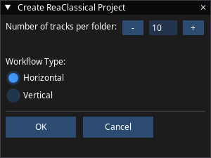

### Notes

#### Track Count

A folder can contain as few as one track. Choosing a single track per folder is intended for a single stereo pair: ReaClassical still builds each folder with two tracks, but the second is kept as a hidden "spare" that can never record, so the folder structure stays consistent everywhere. Folder navigation and Mission Control skip the spare, and adding or deleting tracks later keeps it correctly hidden. Choose two or more tracks per folder for multi-microphone setups.

#### Workflow Choice

A *horizontal* workflow approach means that recorded or imported takes are arranged left-to-right in a single folder. A *vertical* workflow approach is designed for recorded takes of similar material to be stacked vertically.

Warning

You cannot make folders within folders in ReaClassical. Think of it like using a digital or analogue console. There are plenty of ways to control sets of tracks including routing through submixes via Mission Control.

### Mission Control

As soon as you press `OK`, you will see the Mission Control window.

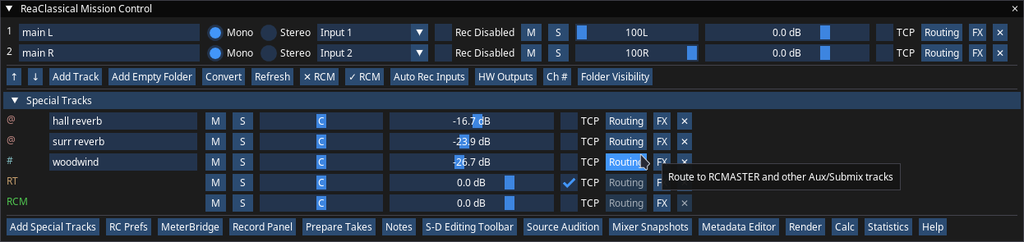

Use this dialog to:

- Name or rename tracks
- Set recording inputs manually or automatically based on track naming
- Temporarily disable recording of a channel
- Set routing
- Add "special" tracks: aux, submix, room tone, reference, live bounce, listenback, talkback, playback and notes (see Special Tracks below)
- Change visibility of folders and special tracks in the arrange window (including showing only the destination folder in one click)
- Add a track to all folders
- Delete a track from all folders
- Re-order tracks in all folders, and move aux and submix tracks up and down
- Convert between horizontal and vertical workflows
- Give mixer tracks direct connections to hardware outputs (if mixing using external gear)

Warning

Do not attempt to complete any of the above actions outside of Mission Control!

Additionally you can use Mission Control to optionally:

- Reach other important ReaClassical windows via a button click
- Add FX, set volume, panning, mute/solo

Screen reader users (Clara)

Create Project and Mission Control each have a keyboard-driven equivalent: Accessible Create Project and Accessible Track Setup. Both are announced through Clara. In Mission Control the "Toggle GUI Mode" action (`Ctrl+Alt+Shift+G`) switches between the accessible window and the standard ReaImGui window. See Using ReaClassical with a Screen Reader.

#### Folder Visibility

In a vertical workflow, the `Folder Visibility` button lists every folder with a checkbox to show or hide it in the arrange window. Once editing is done, click `Destination Only` to hide all source folders at once, and `Show All` to bring them back. Set "D: track height (px)" to resize the destination tracks when you click `Destination Only` (for example 200 to 300 pixels for comfortable navigation and edit refinement). `Show All` restores their previous heights. Leave the height at 0 to keep the current heights. Both are also available as actions, **Destination Only** (`Ctrl+Alt+D`) and **Show All Folders** (`Alt+Shift+D`), so you can put them on a shortcut or a control surface such as a Stream Deck. They use the same height setting and work whether or not Mission Control is open.

### Special Tracks

Special tracks live alongside the mixer tracks rather than inside your folders. Add them with the Mission Control `Add Special Tracks` button: enter how many of each you want and press `OK`. You can add up to 99 each of aux, submix and reference tracks, but only one each of room tone, live bounce, listenback, talkback, playback and notes (the dialog shows "(already exists)" once you have one). The live bounce option only appears in a horizontal workflow.

Once added, each special track is listed in the Mission Control Special Tracks section with mute, solo, pan and volume controls, a TCP checkbox to show it in the arrange window, a Routing button, an FX button and a delete button (RCMASTER itself cannot be deleted). Aux, submix and reference tracks can also be renamed there, and aux and submix tracks can be moved left or right in the mixer with the arrow buttons.

#### Aux and Submix Tracks

Aux (`@`) and submix (`#`) tracks are busses that appear in the mixer only, unless you tick their TCP checkbox. Each feeds RCMASTER. ReaClassical treats them in the same way, so the difference is in how you use them:

- Use an **aux** for effects shared by many tracks, such as a reverb bus.
- Use a **submix** to collect related tracks, such as all the microphones on one orchestral section, so you can balance them together.

To send a mixer track to an aux or submix, click the mixer track's `Routing` button in Mission Control and tick the destination. Untick RCMASTER there if the track should only reach the master bus via a submix. An aux or submix has its own Routing button too, so you can route one aux or submix into another as well as to RCMASTER.

#### Room Tone Track

A single room tone track sits before RCMASTER, is shown in the arrange window and feeds RCMASTER. When you add it, ReaClassical imports `roomtone.wav` from your project's media folder onto it if one exists. Creating CD markers then trims the room tone to the length of the album and adds the fades. See Room Tone Generation and the room tone notes in the mastering section.

#### Reference Track

A reference track (`REF`) sits just after RCMASTER, outside the RCMASTER structure, so it is not part of your mix. Import another recording onto it and hover over it with `A` to audition it and A/B against your own production. By default it is used this way; to use it as an overdub track instead, see Overdub recording and the reference track option in Preferences `F5`.

#### Live Bounce Track

In a horizontal workflow, the live bounce track (`LIVE`) receives a send from RCMASTER and records the rough balanced stereo mix while you record the individual channels. See Live Bounce.

#### Listenback Track

The listenback track (`LISTENBACK`) lets you hear a musician who is far away from the recording setup. It is shown in the mixer only, is record-armed with input monitoring on and records nothing. Choose its input channel from the dropdown in the Special Tracks section. Monitoring mutes automatically during playback and recording unless you set the monitoring JSFX to "Always On". See Listenback.

#### Talkback Track

The talkback track (`TALKBACK`) sends a producer's mic to a speaker in the studio. It is shown in the mixer only, is record-armed with input monitoring on and records nothing. It has no master send, so it never reaches RCMASTER, the monitors or the headphones, and it ignores solo. It stays live during recording, so you can say "we're recording" after pressing record. Choose its mic input from the dropdown in the Special Tracks section and its output with `HW Outputs`. It is created muted: unmute it with its mute button or run **Toggle Talkback**. See Talkback.

#### Playback Track

The playback track (`PLAYBACK`) is a mixer-only monitoring track that receives the RCMASTER mix. It is created muted, and you choose the pair of hardware outputs it plays through from the dropdown in the Special Tracks section. Press `Ctrl+Alt+Shift+P` to unmute it when you want to monitor playback on those outputs. It does not feed the master bus.

#### Notes Track

The notes track (`NOTES`) holds empty items used like post-it notes: run **Add Note at Cursor** (`Alt+N`) to add a note item at the edit cursor (or at the play position during playback) and open its item notes straight away. If a time selection is set while stopped, the note item spans it. If there is no notes track yet, it is created for you. You can also add an empty item yourself (Insert > Empty item) and type into its item notes. It sits after RCMASTER, has no inputs, outputs or mixer channel, and is never record-armed. It is for note items only: any item containing audio or MIDI is removed automatically when the project syncs and when Mission Control opens, with a message saying how many were removed. Unlike other tracks you add outside Mission Control, a track named `NOTES` is kept and turned into the notes track automatically.

- ← Previous
- ↑ Up
- Next →

## Converting a Standard REAPER Project

ReaClassical has the ability to import any REAPER project (available in the top ReaClassical menu via `Project Management > Convert REAPER project`). Because of the dizzying amount of custom routing and folder hierachy that is possible inside a standard REAPER project, the following occurs during conversion:

1. A new project tab is created and `_converted` suffix added to the RPP file
2. Any folders are flattened
3. If more than one track has items, you choose how to treat them (see below)
4. Any empty tracks are deleted
5. A single folder is formed in preparation for a horizontal workflow
6. Any effects are moved to the relevant mixer tracks
7. Any custom routing is removed

The conversion window explains these steps before anything changes. Click **Convert** (or, with several tracks, the option that describes them) to go ahead; when it finishes, the window closes and Mission Control opens. At this point, a horizontal workflow is set up and all that is left for the engineer to do is recreate any custom routing using Mission Control. For example, if the original REAPER project used folders to organize orchestral section microphone channels, this would be recreated by clicking on the appropriate routing buttons to disconnect from RCMaster and instead route to one or more newly-created submix tracks.

### Microphones or Separate Material

When more than one track has items, a window asks what the tracks contain:

- **Microphones of one recording:** the usual case for a classical session. The tracks become one folder with one track per microphone. Existing markers and regions stay where they are.
- **Separate material:** each track holds different material, such as separate pieces, takes or alternative versions, all starting near the beginning of the timeline. The tracks are placed one after another, left to right, in a single-track folder, the same as a single-track ReaClassical project, separated by the Smart Import take gap (2 seconds by default). Each track's items keep their timing relative to one another, and a marker named after the original track marks where its material starts. Track FX and automation are kept from the first track only. The combined track is named after the project file (for example `apoclypse flower` for `apoclypse flower.rpp`); you can rename it in Mission Control.

  If the project already has markers or regions (rehearsal letters, for example), choose which track they belong to from **Existing markers and regions belong to**. They move with that track's material. ReaClassical preselects the track whose material spans all of them; choose **Leave in place** to keep them at their original positions.

Click **Cancel** or close the window to leave the project unconverted.

Screen reader users (Clara)

The choice is announced as a list: `↑` and `↓` move between **Microphones of one recording** and **Separate material** (each is read with a short description), `Enter` converts and `Escape` cancels. The steps above are read out first, and "Project converted" is announced when it finishes. With a single track, there is no list: press `Enter` to convert. If you choose **Separate material** and the project has markers or regions, a second list asks which track they belong to: `↑` and `↓` choose a track or Leave in place, `Enter` converts and `Escape` goes back.

A project whose material is on a single track (either from the start or after choosing **Separate material**) becomes a single-track folder too.

- ← Previous
- ↑ Up
- Next →

## ReaClassical Preferences

Open via `F5` or via Mission Control `C`. Use the reset button to return every option to its default. Here is a brief description for each one:

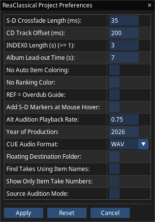

**S-D Crossfade Length (ms)**

The xfade length for all S-D edit functions. Default = 35ms.

**CD Track Offset (ms)**

The negative offset where CD markers are placed to the left of item starts. This is really for old CD players that could not process quick enough and skipped the start of audio. Default = 200ms.

**INDEX0 Length (s) (>= 1)**

If you add an exclamation mark to your CD track name in the metadata editor window, a countdown of this set length will visually appear on some CD Players. Default = 3 seconds.

**Album Lead-out Time (s)**

The amount of silence automatically set at the end of the album. Default = 7 seconds.

**No Auto Item Coloring**

To remove all automatic coloring of items, set to checked. You can still color items manually via the Colorize function `K` or add ranking colors via Record Panel or Notes. Default = unchecked.

**No Ranking Color**

To remove all ranking colors, set to checked. You can still color items manually via the Colorize function `K`. Default = unchecked.

**REF = Overdub Guide**

By default, the reference track acts as a way to A/B project material with an external reference audio file. To use as an overdub track see overdub. Default = unchecked.

**Add S-D Markers at Mouse Hover**

To avoid needing the track to be selected before placing S-D markers, set to checked. This also allows for opening the fade editor `F` by hover. Default = unchecked.

**Alt Audition Playback Rate**

The playrate used when using `Shift+A` etc. Default = x0.75.

**Year of Production**

Default = The year the project was created.

**CUE Audio Format**

The audio format that will be rendered to pair with the CUE file. Default = WAV.

**Floating Destination Folder**

For users who wish to always use the top folder as destination, this visually moves the destination folder just above the placement of source markers, making working in vertical workflow even easier without need for manual vertical scrolling. Note that when checked, the new S-D editing anywhere to anywhere is disabled and destination markers are always associated with the first folder. Default = unchecked.

**Find Takes Using Item Names**

If the audio material was not recorded in ReaClassical and the filenaming does not include a take number as a suffix, you can find takes based on item names instead by checking the option. Default = unchecked.

**Show Only Item Take Numbers**

By default, the item names show both session name (if present) and take numbers. For quicker visual location, set to checked to only show padded take numbers. Not available during the album mastering phase. Default = unchecked.

**Source Audition Mode**

By default, when setting source in and out markers, any previously existing ones are deleted. To convert previous pairs to take marker "regions" for use in the source audition manager `Z`, set to checked. Default = unchecked.

**Marker Offset During Rec/Play (s)**

When adding a marker while recording or playing, the marker is placed this many seconds before the current position to allow for reaction time. Set to 0 to disable. Negative values are not allowed. Default = 0.

**Play Edit After Making It**

After an S-D edit (`5`), a timestretched replace edit (`F4`) or a 3-point insert edit (`F3`), ReaClassical starts playback shortly before the edit point (see Edit Playback Pre-roll) so you can review the edit and its crossfades straight away. If there is no destination material before the edit point, for example on the first edit of a piece, playback starts at the edit point instead. Playback keeps running until you stop it. In dual-tab editing (with source and destination project markers), every edit switches to the destination tab to play, stopping playback in the source tab first, and this setting and the pre-roll are taken from the destination project. Default = unchecked.

**Global Take Numbers**

Adds a project-wide take counter alongside the session take numbers. Every recorded take gets the next global number, whatever its session, which helps keep audio takes in step with globally numbered video files. The number is shown in the top-left corner of the Record Panel, can be set in Record Panel settings, and appears in the take sheet. It is also added to the start of the filenames that Quick Export Recorded Takes produces (for example `G042_Aria_T003.wav`). It is stored with each item and does not change recorded file or item names. Default = unchecked.

**Edit Playback Pre-roll (s)**

How many seconds before the edit point playback starts when Play Edit After Making It is enabled. Decimals are allowed. Set to 0 to always start at the edit point. Default = 3.

Screen reader users (Clara)

Accessible Preferences offers the same nineteen options as a keyboard-driven list: Up and Down move between options, Enter edits, Backspace resets the current option to its default and Escape closes. A "Reset All to Defaults" row restores everything. An additional "Other Settings" row holds three accessibility-oriented values: the marker/item nudge amount in milliseconds, the item edge grow/shrink amount in milliseconds (default 500) and the modifier multiplier applied by the "x modifier" versions of the nudge and grow/shrink actions.

- ← Previous
- ↑ Up
- Next →

## Too Long; Didn't Read

I highly encourage the user to read the full workflows documentation for the best chance of becoming an expert in ReaClassical. However, if time is short and you have an upcoming project for which you need to learn just enough to become dangerous, read the following quick workflow summaries.

### Create a ReaClassical project

If not done already, create a new ReaClassical project via `Ctrl+N` (`Cmd+N` on macOS). The number of tracks should equal the combined number of stereo and mono microphone channels. If in doubt, pick a *horizontal* workflow.

### Quick Setup

1. Open Mission Control via `C`
2. Name your tracks. Use suffixes like "left", "R", "Pair" etc so the automatic record input button can make intelligent decisions
3. If planning to record, manually or automatically set your record inputs

Important

Save your project before continuing with other workflows.

### Recording

1. Select a parent track of a folder
2. Press `F9`. This opens the ReaClassical Record Panel (also available directly via `Alt+Enter`) and arms the selected folder. Optionally set a session name by clicking the "Session name" text beneath the take number and typing.
3. Monitor your signal
4. Use the left-most buttons in the panel (or `F9` again) to control recording, pausing and stopping
5. Add ranking and notes while recording or after the fact
6. Once all recording is completed, close the record panel (automatically disengages record-armed tracks).
7. To give the musicians or the producer the takes so far, press `Ctrl+Shift+D` (Distribute Takes) to export all or selected takes as WAV, FLAC, Opus 160 or MP3 320

### Importing

While it is always better to record in ReaClassical, occasionally you might need to use audio recorded by other engineers who used a different DAW.

#### Smart Import

Assuming that the filenaming contains at least a track name and take number separated by underscore e.g. `cello_004.wav` or `cello_T004.wav`:

1. Ensure that you have first created an empty horizontal or vertical workflow ReaClassical project.
2. Copy or move source material into the media subfolder inside your ReaClassical project folder (or the custom recording path set in Project Settings `P`, on the Media tab).
3. Ensure that track names in the project match the channel text in the filenames
4. If your filenames also contain a session name prior to the track name, the items will be grouped accordingly.
5. Via the top ReaClassical menu, click on `Project Management > Smart Import Audio` (`Ctrl+Alt+Shift+I`) and, if using vertical workflow, choose distribution options.
6. Open Mission Control to add special tracks such as aux & submix, make routing adjustments etc.

#### Manual Import by Dragging

1. In your source folder, select items that should be aligned vertically (for example, every channel for particular take) and drag into the ReaClassical project being sure to drop onto one of the folders created by ReaClassical with a track count that matches the number of files you selected. Choose the option "Same time position on separate tracks"
2. Continue as above for each take
3. Open Mission Control `C` to add special tracks such as aux & submix, make routing adjustments etc.

### Auditioning

Audition your material via mouse hover + `A` on parent or child tracks. Use mixer mute and solo buttons to further customize what you hear.

### Editing

1. Set destination IN and OUT markers via `1` and `2`
2. Set source IN and OUT markers via `3` and `4`
3. Press `5` to make the source-destination edit (2-, 3- or 4-point edit depending on how many markers you set), or `F4` to make a time-stretched S-D edit (requires all 4 markers), or if only using destination IN marker and both source markers, `F3` for an "assembly" or 3-point "insert" edit
4. To finesse the edit, click on the right item of a crossfade pair and press `F`

### Mixing

1. Add FX, change routing, and optionally adjust volume, panning etc via Mission Control `C`
2. For level changes over a passage (for example, pulling down a spot microphone), select the destination or source track, make a time selection and press `I`. Set the level and optional ramp in/out lengths and click `Apply Automation`. A time selection is required
3. For "scenes" that change the whole mixer from one album piece to the next, open the Mixer Snapshot Manager via `Shift+M`, select an item on the first (destination) folder, adjust the mixer and click `Set Snapshot...`. Snapshots are tied to items and are recalled automatically during playback
4. Before rendering, click `Convert to Automation` in the Snapshot Manager to turn the snapshots into real automation

### Mastering

1. The album is built on the first (destination) folder, so make sure your finished edit is there
2. Remove all names from items on the parent track aside from those you want to be track starts. You can clear all items on the folder track via `Ctrl+T`
3. Enter track start names via the Notes window `N`
4. Press `Y` to open the metadata editor

### Rendering

1. Press `Y` to open the DDP Metadata Editor
2. Choose the sample rate, bit depth and dither (and a track range if you only need some CD tracks)
3. Click one of the **Render** buttons at the bottom of the window (DDP, Cue Audio, WAV, FLAC, Opus 160, MP3 320 or M: Stems), or **Custom** to open REAPER's render dialog first. For a quick loudness and peak check, use the dry run option in REAPER's render dialog (`R`)

Screen reader users (Clara)

Every workflow above has a keyboard-driven, screen-reader-friendly equivalent. See the Accessibility section for the overview and each workflow chapter for the details.

- ← Previous
- ↑ Up
- Next →

# Accessibility

## This section contains the following topics:

- Using ReaClassical with a Screen Reader
- Getting Started with a Screen Reader
- Recording with a Screen Reader
- Importing with a Screen Reader
- Navigating a Project with a Screen Reader
- Project Management with a Screen Reader
- Auditioning with a Screen Reader
- Editing with a Screen Reader
- Mixing with a Screen Reader
- Mastering and Rendering with a Screen Reader
- Keyboard Modes
- The Terminal
- ← Previous
- ↑ Up
- Next →

## Using ReaClassical with a Screen Reader

ReaClassical is designed so that a blind or low-vision engineer can carry out a complete classical production, from creating a project through recording, editing, mixing, mastering and rendering, using only the keyboard and a screen reader. This section explains how that works. Each workflow chapter also contains short, purple **Screen reader users** notes wherever the keyboard-driven path differs from the standard one.

### How This Section Is Organized

This section is meant to be a complete guide to ReaClassical for blind and low-vision engineers. Read Getting Started with a Screen Reader first, then follow the production through the chapters that mirror the workflow chapters elsewhere in the manual. Keyboard Modes and The Terminal are reference chapters for the modal keyboard controls and the command box.

### Clara

**Clara** is the accessibility bridge that lets ReaClassical speak through your screen reader. It is a REAPER extension available for Windows and macOS. When Clara is installed:

- ReaClassical announces what it is doing (for example, the take number, the timeline position, the result of an edit) instead of relying on something you must see on screen
- Windows that are mouse-driven for sighted users, such as Mission Control, Notes, Preferences and the DDP Metadata Editor, open as keyboard-driven accessible windows instead
- Where a window offers many options, pressing `H` inside it opens a list of that window's shortcuts that you can step through one at a time with the Up and Down arrows

To install Clara, open the Terminal (`Ctrl+Enter`) and type `clara`. See The Terminal. Clara is installed into your ReaClassical folder and REAPER restarts to load it.

### Accessible Windows and Standard Windows

Every accessible window has a standard (ReaImGui) counterpart for sighted collaborators. Press `Ctrl+Alt+Shift+G` (Toggle GUI Mode) to switch between them. Any Mission Control, Notes, Preferences, Mixer Snapshots or DDP Metadata Editor window that is open notices the change and reopens in the other mode. This only applies while Clara is installed; without it, the standard windows are always used.

### Announcements

ReaClassical provides quick announcements that you can trigger at any time:

| Shortcut | Announces |
| --- | --- |
| `T` | Current take number |
| `Shift+T` | Highest take number |
| `Ctrl+Shift+J` | Timeline position |
| `Alt+Shift+J` | Time within the current item |
| `Alt+F` | Items in the current folder |
| `Alt+P` | RCMASTER peak level |
| `!` | Repeats the last announcement |

The Mixer Mode window (`Alt+S`) lets you move through mixer tracks and hear their input and status.

### Keyboard-Driven Windows

| Shortcut | Window |
| --- | --- |
| `Ctrl+Alt+Shift+R` | Recording Settings: session name, take number, schedule, overlapping and horizontal takes, clip reporting |
| `Ctrl+Alt+Shift+F9` | Close Recording Session (stops the Record Panel Daemon) |
| `Ctrl+R` | Item Rank, with note-taking and item navigation |
| `Shift+N` | Item Name |
| `V` | Item Edit Mode |
| `Alt+S` | Mixer Mode |
| `Ctrl+Alt+Shift+G` | Toggle between accessible and standard windows |

Other accessible windows include Create Project, Track Setup, Smart Import, Distribute Takes, Fix Crossfade Sequence Edits, Automation Navigator, Edit Automation, Mixer Track Grouping, Snapshot Settings, Playback Rate, Peak and Overs Check, Audio Calculator, Show Statistics and Preferences. With Clara installed they replace the standard windows of the same name; see the Keyboard Shortcuts reference for their keys.

### Keyboard Modes

For tasks that need many keys, ReaClassical has keyboard modes: Crossfade Mode (`F`), Item Edit Mode (`V`), Mixer Mode (`Alt+S`) and an automatic Recording mode. `Ctrl+Alt+Shift+E` always returns you to the normal keys. See Keyboard Modes.

### Not Using a Screen Reader?

The accessible windows are built for screen reader users, and if you can see the screen you will normally prefer the graphical windows. The keyboard shortcuts, however, are a very fast way for anyone to work. If you want to experiment without Clara installed, the Terminal command `debug=on` prints announcements to the REAPER console and turns the accessible windows on for the current project.

- ← Previous
- ↑ Up
- Next →

## Getting Started with a Screen Reader

This chapter takes you from nothing installed to a named, ready-to-record project using only the keyboard and a screen reader. Each later chapter in this section follows a stage of the production in the same way, and the workflow chapters elsewhere in the manual link here whenever the screen reader route differs.

### 1. Install ReaClassical

Run the install command for your operating system from a terminal (macOS and Linux) or PowerShell (Windows), exactly as described in Install. The installer prints its progress as it works, asks where to install and creates a self-contained `ReaClassical_<version>` folder.

### 2. Install Clara

Clara is the accessibility bridge that lets ReaClassical speak through your screen reader. It is available for Windows and macOS.

1. Launch REAPER from the new ReaClassical folder.
2. Open the Terminal with `Ctrl+Enter`. A single-line input box asks for a "Command:".
3. Type `clara` and press `Enter`.

Clara is downloaded and installed, any old OSARA plugin in the UserPlugins folder is removed, and REAPER restarts. From then on ReaClassical announces its actions, and its windows open as accessible, keyboard-driven versions. If you want to test announcements without Clara, the Terminal command `debug=on` prints them to the REAPER console and turns the accessible windows on for the current project; it is stored per project, so a new project starts with it off.

### 3. Create a project

Press `Ctrl+N` (`Cmd+N` on macOS). The accessible Create Project walkthrough opens and speaks each step:

1. An input box asks for the number of tracks per folder. The minimum is one, which creates a single stereo track per folder.
2. Choose a **Horizontal** or **Vertical** workflow with `↑` and `↓` and press `Enter`. A horizontal workflow lays takes out left to right in one folder; a vertical workflow keeps like material together, with the takes of the same piece in separate, aligned folders. Neither is better (see Project Setup); you can convert later in Track Setup.
3. For a vertical workflow, an input box asks for the number of source folders.

ReaClassical then hands you straight on to Track Setup so you can name your tracks.

### 4. Track Setup

Track Setup is the accessible counterpart of Mission Control. Open it at any time with `C`. Use `↑` and `↓` to move through the menu (it wraps round), `Enter` to choose an item and `Escape` to go back. Press `H` for a list of the shortcuts that apply where you are. The main menu is:

- **Track Naming**: steps through every mixer track in turn so you can type a name for each. Use suffixes such as "left", "R" or "Pair" so that the automatic input assignment can work out which hardware input belongs to which track
- **Add Track** and **Remove Track**: add a track to every folder (leave the name empty for a default name) or delete one from every folder
- **Reorder Track** and **Reorder Aux/Submix**: pick up a track, move it, and put it down again; the audio and the assigned inputs move with it
- **Special Track Naming**, **Add Special Track** and **Remove Special Track**: aux, submix, reference, room tone, live bounce, listenback, talkback and playback tracks
- **Other Commands**: Convert Workflow, Connect All to RCM, Disconnect All from RCM, Auto Assign HW Outputs, Clear All HW Outputs and Solo-Safe RCM Outputs (announced as on or off; `Enter` toggles it)
- **Mixer Control**: work on a mixer track's FX chain and routing
- **Set Inputs**: assign recording inputs, **Auto** (from the track names) or **Manual**

Every change you make here goes through the same code as the equivalent Terminal command, so the result is identical and is confirmed aloud. As in Mission Control, do all track management here and never directly in REAPER. See Mission Control for what each of these does.

### 5. Set your preferences

Press `F5` to open Accessible Preferences. `↑` and `↓` move between options, `Enter` edits one, `Backspace` resets it to its default and `Escape` closes. A **Reset All to Defaults** row restores everything, and an **Other Settings** row holds the nudge amount, the item edge grow/shrink amount and the modifier multiplier. See Preferences.

### 6. Finding your way around

- **`H` inside a window** lists that window's shortcuts for you to step through one at a time.
- **`Ctrl+Alt+Shift+H` (Menu Help)** walks through the whole ReaClassical menu, announcing the shortcut beside each item. Up and Down browse a level, Enter opens a submenu or runs an item and Escape steps back.
- **`!`** repeats the last announcement.
- **Terminal `help`** opens the full Terminal command guide.
- **`Ctrl+Alt+Shift+E` (Exit Mode)** always returns you to the normal keys from any keyboard mode.
- **`Alt+K` (Panic Mute)** silences everything that can reach your hardware outputs, and unmutes only what it muted.

If a window loses focus, pressing its shortcut again closes it and opens a fresh, focused one.

- ← Previous
- ↑ Up
- Next →

## Recording with a Screen Reader

Everything the Record Panel does for sighted engineers is done for you by the **Record Panel Daemon**, a background process that keeps the take counter, the session name and the schedule, and speaks the result of each action. You never need to open or use the Record Panel itself.

### Before You Record

1. Make sure every track has a recording input. Open Track Setup (`C`) and choose **Set Inputs**: **Auto** assigns inputs from the track names (suffixes such as "left", "R" or "Pair"), **Manual** lets you choose each one. If you try to record without any inputs set, you hear "No inputs set -- please assign inputs before recording".
2. Optionally set the session details in **Accessible Recording Settings** (`Ctrl+Alt+Shift+R`). It lists the session name, the take number, the scheduled start, end and duration, and switches for allowing takes anywhere, recording takes horizontally and clip reporting, plus a row to start or stop the daemon. Move with `↑` and `↓` and press `Enter` to change a row. Changing the session name resets the take number to 1, and switching to an existing session name works out the next take number from the takes already recorded.
3. Select the parent track of the folder you want to record into.

### Recording

Everything is driven by `F9`:

1. The first press starts the daemon (if it is not running) and arms the folder. You hear "Armed for take 12", or "Folder armed" if there is no session take counter to report.
2. The second press starts recording: "Recording take 12".
3. The next press stops it: "Recording Stopped".

There is no need to position the edit cursor first: arming moves the recording position to after the final item in the armed folder.

During a recording:

- `Shift+F9` increases the take number, useful after a false start
- `Alt+F9` starts the next recording section. In a vertical workflow this arms the first source folder, and in both workflows it places the edit cursor 5 seconds after the final item in the project. With "record takes horizontally" on, it arms the next folder down instead
- `Ctrl+F9` pauses
- `Alt+A` announces the take number, `Shift+T` the highest take, and `Ctrl+Shift+J` the timeline position
- `M` adds a marker

A restricted set of keys is active while you record, so that nothing disruptive can be pressed by accident. See Recording mode.

### Sending Every Take to Someone on Location

`Ctrl+Shift+D` (**Distribute Takes**) exports takes as WAV, FLAC, Opus 160 or MP3 320, to share with musicians or a producer. It has four rows: **Render Settings**, **Takes** (all, a take list, selected items or time selection), **Ranking in filenames** (excluded by default) and **Export**. See Distributing Takes On Location.

### Ranking and Notes

After a take, select its item on the parent track and open **Item Rank** with `Ctrl+R`. The list is circular: **No Rank**, **Excellent**, **Very Good**, **Good**, **OK**, **Below Average**, **Poor**, **Unusable** and **False Start**. `↑` and `↓` move through it, `Enter` applies the highlighted rank and `Backspace` clears it. The window stays open, so you can rank several items in one sitting: `←` and `→` (or `Q` and `W`) move to the previous and next item, `Space` plays and stops, and `Escape` closes it. The Terminal command `ir=` sets a rank too.

Item notes, project and track notes, the item name and the take number are in the accessible Notes window (`N`), and `Shift+N` opens a quick Item Name window. See Typing Notes.

### Special Tracks While Recording

Add a **live bounce** track (horizontal workflow only) to record a rough stereo mix alongside the individual channels, or a **listenback** track to hear a musician far from the recording setup, from Track Setup under **Add Special Track**. Listenback monitoring mutes automatically during playback and recording. A **talkback** track sends a producer's mic to a studio speaker only: it is never recorded, stays live during recording and ignores solo. It is added muted. Set its output in Track Setup's **Mixer Control**: select Talkback and press `O`. Then run **Toggle Talkback** to talk. In Mixer Control, `I` announces the listenback or talkback input and `Shift+I` changes it.

### Monitoring and Playback

- `Ctrl+Shift+A` (**Toggle Monitor**) cycles input monitoring on all input tracks that are not disabled for recording, and announces the new state: "Monitor: off", "Monitor: on" or "Monitor: tape mode"
- `Ctrl+Alt+Shift+P` (**Toggle Playback**) mutes or unmutes the playback track ("Playback unmuted" or "Playback muted"). The track is created muted. If there is no playback track you are told so
- `M` adds a marker while recording, which you can later use to split a take into subtakes with `Shift+S`; `Alt+M` gives a marker a name
- `Alt+T` (**Take Number Display**) opens a small window showing the current take number for a sighted colleague. The daemon opens it automatically

### Finishing

When all recording is done, press `Ctrl+Alt+Shift+F9` (**Close Recording Session**) to stop the daemon. This disarms the record-armed tracks, the same as closing the Record Panel does for sighted users. The **Disarm All Tracks** action does the same job for the tracks alone, and you can always switch the daemon off from Accessible Recording Settings.

### Checking Your Levels and Disk Space

- `Alt+P` announces the RCMASTER peak level. In Mixer Mode, `Enter` announces the current mixer track's status and `I` its input
- The Accessible Audio Calculator works out the disk space needed for a duration of audio, or the time available on a given amount of disk, from units, channel count, sample rate, bit depth and format
- Track peaks are announced as you move between tracks with `↑` and `↓`
- ← Previous
- ↑ Up
- Next →

## Importing with a Screen Reader

Smart Import brings in audio files that are named with a track name and a take number. The screen reader route is a spoken wizard with the same options as the sighted window.

### Preparing the Files

Follow the file naming rules in Importing: the take number comes last, preceded by an underscore (`cello_012.wav` or `morning_cello_T012.wav`), and the part before it is split at underscores into an optional session name and the track name. Put the files in the project's media folder, or the recording path set in REAPER's Project Settings (`P`), and make sure you have already created a ReaClassical project.

### Running Smart Import

Press `Ctrl+Alt+Shift+I`. ReaClassical announces "Scanning files in project media folder" and then "Scan complete". If the folder also contains multi-channel files, you are first asked to choose between **Import Takes** and **Import Polywav**, using `↑` and `↓` and `Enter`; otherwise it goes straight to the takes wizard.

The **takes** wizard offers, in turn:

- **Track name order**: if the project's tracks have no names yet, this assigns the names found in the filenames to the tracks. The list is in the order the names will be assigned. Pick an entry up, move it up or down and drop it, as in Track Setup's Reorder Track; entries moved past the divider are "not used this run"
- **Distribution** (vertical workflow only): **One folder per take**, **Use current folder count**, or **Round-robin across a custom number of folders** (you are asked for the number, with a minimum of 1), and the starting folder
- **Import only these takes** (optional): a session name, and a list of takes such as `1-3,5,11-15`
- A final **confirmation** step before anything changes in the project

Material is inserted at the edit cursor, and files that are already used in the project are ignored. Afterwards, open Track Setup to add aux and submix tracks and adjust the routing.

### Multi-Channel Files from a Portable Recorder

Choose **Import Polywav** to split multi-channel files into mono and stereo tracks. Name the files `[sessionname_]Txxx.wav` (or `[sessionname_]Txxx_xxxx.wav` for a recording split into several files), and enter a channel composition pattern of the digits 1 (mono) and 2 (stereo), for example `221`. Enter opens a box to set the pattern (keep or change it there), and ReaClassical tells you how many tracks it gives or why it can't be used. A usable pattern moves on, with the same distribution options as the takes wizard in a vertical project, and a final Enter imports. If the media folder contains only multi-channel files, you go straight to this step. See Multi-Channel Files from a Portable Recorder for how the pattern is applied.

Files from a recording that was split into several parts, such as `cello_T003_0001.wav` and `cello_T003_0002.wav`, are joined into one continuous take in both wizards. See Split Recordings. The gap between takes uses the value last set in the Smart Import window for this project (2 seconds if it has never been set).

### Other Imports

- **Import DDP** (`Ctrl+Alt+Shift+D`) and **Import PMI** (`Ctrl+Alt+Shift+M`) rebuild an album layout from an existing master in a fresh project with an empty destination folder
- The Terminal command `import=` runs a Smart Import without the wizard. See The Terminal
- ← Previous
- ↑ Up
- Next →

## Navigating a Project with a Screen Reader

Every move through a ReaClassical project can be made from the keyboard and is announced, so you always know where you are. Mouse navigation also still works as in any REAPER project.

### Tracks and Folders

`↓` and `↑` select the next and previous track in the current folder and announce its name, its peak level and any mute or solo state. In a project with a single track per folder they move between folders instead. `Alt+↓` and `Alt+↑` move to the next and previous folder, and `D` goes to the first folder. Moving to a folder makes it the folder you hear (the others are muted), un-arms any record-armed tracks, selects the item nearest the edit cursor and announces the folder.

If a special track such as an aux, submix or reference is selected, `↓` and `↑` step through the visible special tracks and announce each one with its peak and mute or solo state. At the ends you hear "At bottom of folder", "At bottom of project" or "Last special track".

To go straight to a track, press `Shift+J` and type part of its name.

### Items, Fades and Markers

- `←` and `→` (or `Q` and `W`) move to the previous and next item or fade and announce it as, for example, "Mozart take 3". While editing a crossfade they move through the crossfade, and with an envelope selected they move between its points
- `Alt+←` and `Alt+→` go to the start and end of the selected item
- `Ctrl+Shift+←` and `Ctrl+Shift+→` go to the first and last item on the track
- `Shift+Q` and `Shift+W` go to the start and end of the folder
- `Alt+Q` and `Alt+W` go to the previous and next group of crossfaded items
- `,` and `.` go to the previous and next marker

### Markers, Regions and Time Selection

These actions are silent in REAPER itself; ReaClassical speaks the result of each one.

- `M` adds a marker at the cursor and announces its position. `Alt+M` inserts or edits a marker, which is how you give it a name
- `Ctrl+M` deletes the marker nearest the cursor and says which one. `Ctrl+Shift+M` moves the nearest marker to the cursor and says which one moved and where. `Ctrl+Shift+G` deletes all generic markers ("All generic markers deleted")
- `;` creates a region from each selected item, named after the active take ("3 regions created"), and `Ctrl+Alt+R` deletes all regions ("All regions deleted"). `:` creates a region from the time selection and `L` opens the region and marker manager
- `[` and `]` set the start and end of the time selection at the cursor and announce its position and, once both edges are set, its length in plain words. `Ctrl+]` and `Ctrl+[` move the cursor to the start and end of the time selection and announce the position ("No time selection" if there is none). `/` sets the time selection to the selected items
- `0` deselects all items

### Project Tabs

`Ctrl+Alt+N` opens a new project tab ("New tab") and `Ctrl+Tab` or `NumPad +` switches to the next one, announcing the name of the project you land on. See Multi-Project Tab S-D Editing.

### Jumping to a Time or a Take

- `J` jumps to a time in the project. Type digits that are read from the right, as HH:MM:SS:FF, so `100524` is 10 minutes 5 seconds 24 frames. Start with + or - to move relative to the cursor
- `Ctrl+J` does the same within the selected item or a set of crossfaded items
- `Enter` searches for a take by number using the file name of the media item. Type `G42` (for example) to search by global take number instead. See Finding Takes

### Announcements

These speak without moving anything:

| Shortcut | Announces |
| --- | --- |
| `T` | Current take number |
| `Shift+T` | Highest take number |
| `Alt+F` | Items in the current folder |
| `Ctrl+Shift+J` | Timeline position |
| `Alt+Shift+J` | Time within the current item |
| `Alt+P` | RCMASTER peak level |
| `!` | The last announcement again |

While recording, the take number is on `Alt+A` instead of `T`. In Mixer Mode, `I` announces the input of the current track and `Enter` announces its status.

### Showing and Hiding Children

Select a parent track and press `E` to show or hide its child tracks, so that editing a multi-microphone folder is as simple as editing a stereo track.

- ← Previous
- ↑ Up
- Next →

## Project Management with a Screen Reader

This chapter covers the housekeeping around a production: statistics, notes, folders and backups.

### Notes, Names and Ranks

- `N` opens the accessible **Notes** window with fields for the project note, the track note, and for the selected item its name, rank, take number and item note. `←` and `→` (or `Q` and `W`) move between items while it is open, and `Space` plays and stops
- `Shift+N` opens the quick **Item Name** window
- `Ctrl+R` opens **Item Rank**

### Folders and Items

- `Ctrl+D` (**Duplicate folder (No items)**) adds a copy of the selected folder's tracks as a new folder, without its items. In a horizontal workflow it first asks whether to convert to a vertical workflow. It announces "Folder duplicated"
- `Shift+D` deletes the selected source folder, and `Ctrl+Alt+Shift+Delete` deletes every item in every source folder. Both are for the vertical workflow and ask you to confirm. "No source items found" is announced if there is nothing to delete
- `Ctrl+Alt+A` selects all items in the folder of the selected track. If no track is selected, or the track is not in a ReaClassical folder, you are told
- `Ctrl+V` pastes items and announces how many were pasted

### Backups, Cleaning and Archiving

Backups, cleaning and archiving are REAPER features that work as described in Project Management. ReaClassical sets auto-save to every 15 minutes. Use REAPER's own File menu for Clean current project directory and Save project as.

### Project Tabs

`Ctrl+Alt+N` opens a new project tab and `Ctrl+Tab` moves to the next one, announcing its name. Use separate projects or tabs for the discs of a multi-disc album.

- ← Previous
- ↑ Up
- Next →

## Auditioning with a Screen Reader

Auditioning means hearing a folder, or the area around your editing markers, without touching the mouse.

### Hearing a Folder

Choose the folder with `Alt+↓`, `Alt+↑` or `D` (see Navigating a Project). Moving to a folder makes it the audible one, so there is nothing else to switch. Then:

- `Space` plays and stops
- `Shift+Space` plays and stops, moving the edit cursor along with the playhead
- `Ctrl+Shift+Space` returns to the position where you last stopped

In Mixer Mode, `S` solos the current mixer track and `Shift+S` unsolos everything.

### Hearing the Area Around Your Markers

Once you have set source and destination markers, each of these selects the right folder, makes it audible and plays a short segment, announcing a message if a marker is missing:

| Shortcut | Plays |
| --- | --- |
| `6` / `8` | 3 seconds from the destination IN / OUT marker |
| `7` / `9` | 3 seconds from the source IN / OUT marker |
| `Ctrl+6` / `Ctrl+8` | the 3 seconds up to the destination IN / OUT marker |
| `Ctrl+7` / `Ctrl+9` | the 3 seconds up to the source IN / OUT marker |
| `Alt+6` or `Alt+8` | from the destination IN to the destination OUT marker |
| `Alt+7` or `Alt+9` | from the source IN to the source OUT marker |

Starting a new audition stops any audition still playing. Use `Ctrl+,` and `Ctrl+.` to nudge a marker after hearing it, then audition again.

### Auditioning a Crossfade

In crossfade mode (`F` with Clara installed), `Z` plays 1.5 seconds either side of the crossfade, `X` plays the left item up to the center and `C` plays from the center of the right item. Hold `Ctrl` or `Shift` with the key for a longer, 3 second version. See Keyboard Modes.

Note

The mouse-hover audition keys, `A` and `Shift+A` (which plays at the custom audition rate), find the folder and position from the mouse pointer, so they are not available from the keyboard. A keyboard version is planned.

- ← Previous
- ↑ Up
- Next →

## Editing with a Screen Reader

Source-destination (S-D) editing is fully keyboard-driven, and every marker and edit action is announced. This chapter follows the editing workflow; the full descriptions of each function are in Editing.

### Placing Markers and Making an Edit

Select the folder where you want to place the marker pair (moving to it with `Alt+↓`, `Alt+↑` or `D` selects it), then:

1. Place the destination IN and OUT markers with `1` and `2`
2. Place the source IN and OUT markers with `3` and `4`
3. Press `5` for the source-destination edit, `F4` for a time-stretched edit (all four markers) or `F3` for a 3-point insert edit
4. Hear the result with the audition keys in Auditioning with a Screen Reader: `6` to `9` play around each marker and `Alt+6` / `Alt+7` play between a pair

Each marker announces its position, for example "Added source in @ 1 minute 23 seconds". If you place a marker on the wrong side of its partner (a source OUT before the existing source IN, say), the stale partner is deleted and you are told so, which stops an edit silently taking far more material than you intended.

To move the edit cursor to a marker use `Ctrl+1` to `Ctrl+4`. `Ctrl+,` and `Ctrl+.` nudge a marker left or right by the nudge amount after you have auditioned it; set the amount with the Terminal command `nudge=10` (in milliseconds). `Ctrl+Delete` deletes all S-D markers.

You can also set both source markers to the edges of the selected items with `F12`, or the destination markers with `Ctrl+F12`.

### Deleting

`Backspace` deletes the material between the source IN and OUT markers and ripples later material back with a short crossfade. `Ctrl+Backspace` deletes it and leaves the silence in place.

### Fixing Up the Crossfade

With the right-hand item of the crossfade selected, press `F` to enter **crossfade mode**, the keyboard version of REAPER's two-lane editor. It gives you slip, nudge, shift, widen and narrow, fade length and shape, volume, audition and reset and revert, all announced. See Crossfade Mode for the keys. `Alt+Q` and `Alt+W` jump between crossfade groups.

If items that should be grouped have become misaligned across the tracks of a folder (for example because ripple-per-track was switched off by accident while dragging items), select any one of them and press `Shift+X` (**Fix Crossfade Sequence Edits**). Use `↑` and `↓` to pick which track has the correct edits, `Enter` to run the fix and `Escape` to cancel.

### Working on a Single Item

**Item Edit Mode** (`V`) edits one item's fades, edges and volume from the keyboard. See Item Edit Mode. `Shift+R` opens the accessible **Playback Rate** window, which changes an item's rate (rippling the following items) or its pitch. Press `H` in it for examples.

### Nudging

`Ctrl+,` and `Ctrl+.` nudge the selected marker left and right (each audition from or to a marker selects it automatically), and `Alt+,` and `Alt+.` nudge the selected items. Each nudge is announced, for example "Mozart take 3 nudged 10 milliseconds left". The larger "x modifier" versions are `Ctrl+Alt+,` and `Ctrl+Alt+.` for markers and `Alt+<` and `Alt+>` for items. Set the nudge amount with the Terminal command `nudge=10` (milliseconds) and the multiplier with `mod=10`, or under Other Settings in Accessible Preferences. In crossfade mode, the crossfade nudge keys are used instead and you are reminded of that.

### Other Editing Functions

- `Ctrl+H` heals the selected S-D edit, restoring the material it replaced ("Edit healed"). Selecting any one item of a multi-item edit heals the whole edit
- `Ctrl+F` finds the source material of an edited item and places a source IN and OUT marker pair there, announcing "Source found" with the take
- `X` crossfades two overlapping items when the edit cursor is in the overlap
- `Shift+F` removes the fades from items whose edges are not part of a crossfade ("Non-overlapping item fades removed"), `Ctrl+V` pastes and announces how many items were pasted, and `Ctrl+Alt+A` selects all items in the folder
- `Ctrl+Alt+C` and `Ctrl+Alt+M` copy or move the destination material into a new source folder, and `Ctrl+Alt+P` promotes a source folder to the destination
- `Shift+K` re-applies the automatic item colors; with a screen reader, colors matter less, but take numbers are still extracted for `Enter` (find take)
- Multi-project-tab editing uses `Ctrl+Alt+1` to `Ctrl+Alt+4` to set project markers in other tabs; see Multi-Project Tab S-D Editing

Note

The **Source Audition Manager** (`Z`) is a mouse-driven window and is blocked while the accessible windows are active. A keyboard version has not been written; use the S-D marker keys and the audition keys to compare alternative source takes.

- ← Previous
- ↑ Up
- Next →

## Mixing with a Screen Reader

This chapter follows the mixing workflow. The mixer itself is controlled with **Mixer Mode**, the snapshot manager and the automation windows are keyboard-driven, and every change is announced.

### Setting Up the Mixer

Use Track Setup (`C`) to add FX chains, routing, aux and submix tracks and hardware outputs. Open a track's FX chain or routing from Track Setup's **Mixer Control**, or from Mixer Mode with `F` and `R`. See Getting Started with a Screen Reader.

### Mixer Mode

Press `Alt+S` for Mixer Mode. `↓` and `↑` move between the mixer, aux, submix and other special tracks, and a single key changes the level, pan, mute, solo or polarity of the current track without touching REAPER's track selection. Grouping keys build groups of tracks. See Mixer Mode for every key. Press `Enter` to hear the current track's status and `I` its input.

### Mixer Track Grouping

The accessible **Mixer Track Grouping** window manages groups of mixer tracks. `↑` and `↓` browse the groups and a **New group** row creates one. `Enter` opens a group, where you can rename it, choose which special tracks are members and switch on or off whether each of **mute, solo, pan, fader, automation and polarity** fans out across the group.

### Mixer Snapshots

Snapshots are mixer scenes tied to items on the first (destination) folder.

- To capture one quickly, select an item on the first folder and press `Ctrl+Alt+Shift+S` (**Snapshot Add**)
- `Shift+M` opens the accessible **Snapshot Settings**, which covers the same ground as the sighted Mixer Snapshot Manager: the bank picker, adding and updating a snapshot, browsing, recalling, deleting and annotating existing snapshots, the recall settings (auto-recall, the gap folder, the nine per-parameter recall switches, switching mid-gap and background auto-recall) and converting to or clearing automation
- Before you render, convert to real automation. Snapshots recall in real time and are unreliable in a faster-than-realtime render

See Mixing for how recall, banks and conversion work.

### Volume and FX Automation

`I` opens the **Automation Navigator**, a keyboard walkthrough for inserting automation over a time selection. Make a time selection first. You choose the track (press `Shift+Enter` to toggle several tracks and apply to them in one pass), then the envelope or FX parameter, then the level and optional ramp in and out. You hear the level you are choosing while you dial it in, but ramps cannot be previewed.

`Ctrl+I` opens **Edit Automation** for an existing automation item. `Alt+D` and `Alt+E` show and hide automation lanes, `Shift+←` and `Shift+→` move between automation items and `Ctrl+Shift+↑` and `Ctrl+Shift+↓` move between envelope lanes.

The first time you create an automation item, ReaClassical turns on automation mode, which locks the source-folder items and sets ripple editing to all tracks, so a ripple edit on the destination carries the automation along (in horizontal workflow nothing is locked; only ripple changes). Toggle it with `Shift+I`; ReaClassical announces "Automation mode on" or "Automation mode off".

### Hardware Outputs and Panic Mute

`Ctrl+Alt+Shift+T` toggles the mute on RCMASTER's own hardware output sends. If any is unmuted it mutes them all, and it only unmutes when all are muted. `Alt+K` is Panic Mute, which silences everything that can reach your hardware outputs and later unmutes only the tracks it muted itself. It is available in every keyboard mode.

To send a full mix from RCMASTER's hardware outputs (for example to a video team) while you solo freely on your monitors, turn on **Solo-Safe RCM Outputs** in Track Setup's **Other Commands** (or type `cuesolo=on` in the Terminal; `cuesolo=off` turns it off and `cuesolo?` checks it). Solo in Mixer Mode, Track Setup and the Terminal then only changes what reaches the REAPER master, while RCMASTER's outputs and the live bounce keep the full mix. See Solo-safe RCMASTER outputs.

To trim a hardware output's level, for example -11.8 dB for a +4 dBu interface into a -10 dBV input, select the track in **Mixer Control**, press `O` and then `T`. The output status announces the trim.

### Checking Levels

- `Alt+P` announces the RCMASTER peak level
- `Shift+P` opens the accessible **Peak and Overs Check**, which announces the peak position and the number of overs, moves the edit cursor to the peak and lets you browse the overs
- The Terminal has fast level commands, such as setting a fader or muting by track number. See The Terminal
- ← Previous
- ↑ Up
- Next →

## Mastering and Rendering with a Screen Reader

This chapter takes an edited album through mastering and out to rendered files. The full workflow is described in Mastering and Rendering.

### Setting Up the Album

1. The album is built on the first (destination) folder, so make sure your finished edit is there.
2. Clear all item names on the parent track except those that start a CD track. `Ctrl+T` removes all take names from the folder track.
3. Name the track starts in the accessible Notes window (`N`) or with the quick Item Name window (`Shift+N`).
4. Press `Y` to open the accessible DDP Metadata Editor.

### The DDP Metadata Editor

The editor is a single list. `↑` and `↓` move between the CD tracks, **Render Settings**, **Render**, **Album** and **CD Settings**. `←` and `→` choose which kind of metadata is read out for the current row: title, performer, songwriter, composer, arranger, message and ISRC (the Album row has its own set of fields).

- `Enter` edits the cell you are on in an input box already filled with its value, then stops, so you can press `↓` and `Enter` repeatedly to fill in one field down every track
- `Ctrl+A` applies the current value to every track, `Ctrl+R` to this and the later tracks, `Ctrl+P` copies the previous track's value and `Ctrl+U` copies the album's
- Invalid ISRC and catalog entries reopen the input box. Read-only cells, such as the automatic album contributors and the automatic ISRC on tracks after the first, tell you why they cannot be edited
- **CD Settings** covers Digital Release Only (no CD start offset and no snapping to CD frames), manual ISRC entry, pre and post roll and marker offsets
- On the Album row you enter the album title, performer, songwriter, composer, arranger, genre, identification, language, catalog (EAN/UPC) and message

### Reordering and Offsets

- To move an album track earlier or later, select its named item in the arrange window and press `Ctrl+←` or `Ctrl+→`. It swaps with the track above or below it, gaps are preserved, and any snapshot automation is rebuilt for the new order
- `Ctrl+Y` (**Reposition Album Tracks**) spaces the tracks with a uniform gap in seconds that you enter, leaving crossfaded items intact
- In **CD Settings**, the **Marker Offsets** row adds or clears the CD marker offsets. `Shift+O` and `Alt+O` do the same from anywhere. If a cough or a string noise precedes a downbeat, see Marker Offsets

### Checking and Warnings

Warnings are announced rather than shown in a dialog. Before rendering, ReaClassical checks for characters that DDP and CD-Text cannot hold (anything outside Latin-1, and embedded line breaks), duplicated ISRC codes and tracks without a title. If a room tone track is shorter than the album, you hear how many seconds short it is.

### Rendering

Rendering is part of the same editor:

1. Move to **Render Settings** and press `Enter`. It walks through the sample rate, bit depth and dither in turn (`↑` and `↓` to choose, `Enter` to confirm each)
2. Move to **Render** and press `Enter`. Choose the format: **DDP**, **Cue Audio**, **WAV**, **FLAC**, **Opus 160**, **MP3 320**, **M: Stems** or **Custom**
3. For the per-track formats you are then asked for an optional track range such as `1-3,5`. Leave it empty for every track
4. ReaClassical announces what it is rendering, for example "Rendering FLAC, full album", and renders without opening REAPER's dialog

DDP, Cue Audio and Custom always render the whole album. The files go into the project's `Exports` folder, as described in Rendering.

### Playing the Album Back

`Ctrl+Alt+Shift+Y` opens the **CD Player**, which plays the album back like a physical CD player. Its window needs keyboard focus (press the shortcut again for a fresh, focused one). `P` plays, pauses and resumes, `S` stops, `→` and `←` change track, `↑` and `↓` fast forward and rewind, `D` enters a track number, `1` to `9` jump to a track, `T` cycles the time that is announced (track elapsed or remaining, album elapsed or remaining), `R` cycles repeat (off, track, album) and `Escape` powers off. `B` starts **Transition Review**, which plays each join (the start of the album, every transition and the end) with a pre-roll and post-roll that you set with `W`. Press `H` for the list of keys. See CD Player.

### Checking Peaks and Loudness

`Shift+P` opens the Peak and Overs Check (see Mixing with a Screen Reader). For loudness, REAPER's render dialog can normalize to a loudness target and run a dry run, and the dialog can be opened from the editor's **Custom** button.

### Reports

The metadata editor also writes the album reports (`album_report.html` and `album_report.txt`), `metadata.txt`, and the CUE and CD-Text files, as described in Mastering. The HTML report opens in a browser and is laid out as ordinary headings and tables for a screen reader.

- ← Previous
- ↑ Up
- Next →

## Keyboard Modes

ReaClassical has several keyboard **modes** for screen reader users. Each mode swaps in its own set of single-key shortcuts for one kind of task, so a whole task can be done from the keyboard with every action announced through Clara. Only one mode is active at a time, and the keys listed below work only inside that mode.

- **Crossfade Mode**, started with `F`: edit a crossfade
- **Item Edit Mode**, toggled with `V`: edit one item's fades, edges and gain
- **Mixer Mode**, toggled with `Alt+S`: mix without touching track selection
- **Recording mode**, entered automatically while recording: a restricted, safe set of keys

In every mode, `Ctrl+Alt+Shift+E` (Exit Mode) returns you to the normal keys, and it is safe to press if you are not sure which mode you are in. `Ctrl+Alt+Shift+H` (Menu Help) opens a browsable list of the ReaClassical menu with the shortcut for each item, and `Alt+K` toggles Panic Mute, which silences everything that can reach your hardware outputs (it only unmutes what it muted itself). `Space` plays and stops, and `Q` and `W` move between items, in the same way as outside the modes.

Note

Item Edit Mode and Mixer Mode need Clara. Sighted users work with item fades and the mixer directly, and use REAPER's two-lane crossfade editor in place of Crossfade Mode.

### Crossfade Mode

Press `F` with the right-hand item of a crossfade selected. ReaClassical treats the selected item as the crossfade's right-hand item, and the left-hand item is the one whose end crossfades with it. It selects both of them and their peers across the folder and turns on ripple-per-track until you leave the mode. If the selected item is not the right-hand item of a crossfade, you are told so. Press `F` again to leave. This gives the same control as REAPER's two-lane crossfade editor, which is used instead when Clara is not installed.

Most keys act on the **selected side** of the crossfade: select the left item (`S`), the right item (`D`) or both (`A`).

| Keys | Action |
| --- | --- |
| `A` / `S` / `D` | Select both / the left / the right item |
| `Z` / `X` / `C` | Audition the crossfade (1.5 s either side of its center) / the left item up to the center / the right item from the center |
| `Ctrl+Z` or `Shift+Z`, `Ctrl+X` and so on | The same auditions with twice the length (3 s) |
| `←` / `→` | Slip the item's audio left / right (downstream material ripples) |
| `Ctrl+←` / `Ctrl+→` | Nudge the item left / right |
| `J` / `K` | Shift the crossfade left / right (no ripple) |
| `I` / `U` | Widen / narrow the crossfade |
| `P` / `O` | Grow / shrink the start of the fade |
| `]` / `[` | Grow / shrink the end of the fade |
| `T` | Cycle the fade shape |
| `N` / `M` | Match the right item's fade-in to the left item's fade-out / the reverse |
| `↑` / `↓` | Raise / lower the selected item's volume by 1 dB (`Ctrl+↑` / `Ctrl+↓` for 0.2 dB, `Ctrl+0` to reset) |
| `0` | Reset both fades to a 35 ms equal-power crossfade |
| `Ctrl+Alt+0` | Revert the crossfade to how it was when you first edited it this session |

Slips, nudges, shifts, widening, narrowing and fade changes all move by the project nudge amount (set it with the Terminal command `nudge=20`, in milliseconds). Most actions also have a larger "x modifier" version on the same key with Shift or Ctrl added (for example `Shift+←` or `Ctrl+J`), which moves by the nudge amount multiplied by the modifier amount (Terminal command `mod=10`). Some actions are blocked when both items are selected, because they only make sense for one side.

Each keyboard crossfade action announces what it did, and the Announce Selected Items action tells you whether the left item, the right item or both are selected. Outside crossfade mode, `Alt+Q` and `Alt+W` jump between crossfade groups.

### Item Edit Mode

Toggle with `V`. The mode works on the item that is currently selected, and follows the selection: move to another item with any navigation key (`Left`, `Right`, `Q`, `W` or a click) and the mode announces the new item and which side of the fade is active. Press `V` again to leave.

| Keys | Action |
| --- | --- |
| `S` / `D` | Choose the fade in / the fade out as the active side |
| `I` / `U` | Grow / shrink that fade |
| `T` | Cycle the fade shape |
| `0` | Reset the fade |
| `P` / `O` | Grow / shrink the left edge of the item |
| `]` / `[` | Grow / shrink the right edge of the item |
| `↑` / `↓` | Raise / lower the item's volume by 1 dB (`Ctrl+↑` / `Ctrl+↓` for 0.2 dB, `Ctrl+0` to reset) |
| `Ctrl+S` | Save the project |

Holding Shift with a growing or shrinking key (for example `Shift+I` or `Shift+P`) uses the larger "x modifier" amount. Edges move by the **Item Edge Grow/Shrink Amount** (default 500 ms), and the modifier multiplier applies on top. Set both in Accessible Preferences under Other Settings.

### Mixer Mode

Toggle with `Alt+S`. Mixer Mode acts on a **current target**, a mixer, aux, submix or other special track that you move between with `↓` and `↑`. It never changes REAPER's real track selection, so folder, item and take navigation carries on as normal while you mix. Press `Alt+S` again to leave.

| Keys | Action |
| --- | --- |
| `↓` / `↑` | Next / previous special track |
| `M`, `S`, `P` | Toggle mute, solo, polarity on the target |
| `Shift+M`, `Shift+S`, `Shift+P` | Unmute all, unsolo all, normal polarity on all |
| `=` / `-` | Raise / lower the fader (`+` / `_` for larger steps) |
| `0` or `U` | Fader to unity (`Shift+U` for all tracks) |
| `K` | Fader to minus infinity (`Shift+K` for all tracks) |
| `←` / `→` | Pan left / right (`Shift+←` / `Shift+→` for larger steps) |
| `C` | Center the pan (`Shift+C` for all tracks) |
| `F` | Open the target's FX chain |
| `R` | Open the target's routing |
| `I` | Announce the target's input |
| `Enter` | Announce the target's status |
| `Ctrl+Alt+Shift+S` | Set a mixer snapshot |
| `Shift+J` | Jump to a track by typing part of its name |

Grouping keys: `G` groups tracks (use `Alt+G` to group a multi-selection), `Alt+L` lists the groups, `L` reports the current group, `T` toggles grouping for the current group and `Ctrl+T` toggles it for all groups. `Ctrl+G` removes the current group and `Ctrl+Shift+G` removes all groups.

Navigation also works inside Mixer Mode: `Alt+↓` and `Alt+↑` move between folders, `Shift+D` goes to the first folder, and `Q` and `W` move between items.

### Recording Mode

While a recording is in progress, ReaClassical automatically switches to a restricted set of keys, so nothing disruptive can be pressed by accident. The keys available are:

| Keys | Action |
| --- | --- |
| `F9` | Stop recording |
| `Shift+F9` | Increment the take number |
| `Ctrl+F9` | Pause |
| `Alt+A` / `Shift+T` | Announce the take number / the highest take |
| `Ctrl+Shift+J` | Announce the timeline position |
| `M` | Add a marker |
| `S` | Split items at the cursor |
| `E` | Show or hide children |
| `Ctrl+Alt+→` and similar | Zoom to the whole project |
| `Alt+S` | Mixer Mode (leaving it returns you to Recording mode) |
| `Ctrl+Enter` | The Terminal |

Zoom and view keys are available too. Stopping the recording returns you to the normal keys.

- ← Previous
- ↑ Up
- Next →

## The Terminal

The Terminal is a single text-entry dialog opened with `Ctrl+Enter`. Type a command, press Enter, and ReaClassical carries it out and speaks a confirmation. It is built for screen reader use and covers fast power-mixer moves (mute, solo, pan, fader, peak, polarity), workflow conversion, importing audio, nudge and modifier amounts, and setup utilities.

You can run several commands at once by separating them with a semicolon: `1m;2m;3s` mutes tracks 1 and 2 and solos track 3.

### Setup Commands

| Command | What it does |
| --- | --- |
| `clara` | Download and install Clara (Windows and macOS), then restart REAPER |
| `reaper` | Install the REAPER version ReaClassical has been tested with. `reaper=latest` installs the newest public version and `reaper=752` (for example) a specific one |
| `debug=on` / `debug=off` | Also print announcements to the REAPER console. Stored per project |
| `help` | Open the full Terminal command guide in your browser |

### Full Command Guide

The complete list of commands, with the target syntax used to select tracks, aux and submix tracks, the RCMASTER and reference tracks, is in the [Terminal Command Guide](https://reaclassical.com/rcterminal.html). It is also installed with ReaClassical and opens when you type `help`.

- ← Previous
- ↑ Up
- Next →

# Workflows

## This section contains the following topics:

- Recording
- Importing
- Navigating a Project
- Project Management
- Auditioning
- Editing
- Mixing
- Mastering
- Rendering
- Collaborating with Video Editors
- ← Previous
- ↑ Up
- Next →

## Recording

Now that you have decided on a workflow, we can start recording!

### Manually Setting Inputs

Use Mission Control `C` to set recording inputs and panning manually or automatically based on track name. For automatic assignment, add text like "Left", "R", "Pair", "2ch" etc. as a suffix and press `Auto Rec Inputs`.

### Primary and Secondary Recording Paths

By default, ReaClassical creates a media subfolder within the project directory to serve as the primary location for storing audio files. If a secondary recording folder is specified, all tracks are automatically configured to use it. To set the secondary recording path or change the primary path, open Project Settings by pressing `P`, then select the "Media" tab.

### Easy Steps to Record

1. Select a parent track of a folder
2. Press `F9`. This opens the ReaClassical Record Panel (also available directly via `Alt+Enter`) and arms the selected folder. Optionally set a session name by clicking the "Session name" text beneath the take number and typing.
3. Monitor your signal
4. Use the left-most buttons in the panel (or `F9` again) to control recording, pausing and stopping
5. Add ranking and notes while recording or after the fact
6. Once all recording is completed, close the record panel (automatically disengages record-armed tracks).

Screen reader users (Clara)

No panel is needed: pressing `F9` starts the **Record Panel Daemon**, which runs in the background and keeps track of everything the Record Panel does for sighted users (take counter, session name, scheduled recording and so on). Press `F9` to arm the selected folder, again to start recording and again to stop. Hear the current input and status with the Mixer Mode announcement scripts, and use `!` to repeat the last announcement. Set the session name, take number, scheduled start/end/duration, overlapping takes, horizontal takes and clip reporting in Accessible Recording Settings (`Ctrl+Alt+Shift+R`). When recording is finished, close the daemon with Close Recording Session (`Ctrl+Alt+Shift+F9`). See Using ReaClassical with a Screen Reader for setting up Clara.

Tip

There's no real need to position the edit cursor before starting to record as the arm/record function will automatically move the recording start position to after the final item in the armed folder.

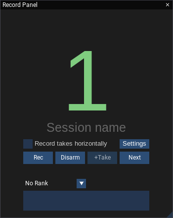

### Distributing Takes On Location

When you are recording on location, you can hand the takes recorded so far to the musicians or the producer without leaving the session. Use **Distribute Takes** (`Ctrl+Shift+D`, called **Quick Export Recorded Takes** in the ReaClassical menu). Choose which takes to export: **All takes**, a **Take list** by number (for example `1,4-6,7`), the **Selected items**, or the takes overlapping the **Time selection**. It builds one region per take (for each folder in the vertical workflow, or the first folder in the horizontal workflow) and renders each one through the mixer to the master as **WAV**, **FLAC**, **Opus 160** or **MP3 320**, using the sample rate, bit depth and dither you choose for WAV and FLAC (Opus and MP3 keep their own fixed settings). The files go into a subfolder of `Exports/Distribute_Takes` named for the format and settings, so exporting again at a different rate or format never overwrites an earlier export. Folders other than the one being rendered are muted for each pass, and your mute states are restored afterwards. Files are named after the take. With Global Take Numbers enabled, each filename starts with the take's global number, for example `G042_Aria_T003.wav`, so the files line up with globally numbered video clips. Takes recorded before Global Take Numbers was enabled keep their plain names. Rankings (such as Excellent or Poor) are left out of filenames unless you check **Include ranking in filenames**.

Screen reader users (Clara)

`Ctrl+Shift+D` opens an accessible version with four rows: **Render Settings** (sample rate, bit depth, dither), **Takes** (all takes, take list, selected items or time selection; choosing take list opens a box for the take numbers), **Ranking in filenames** (press `Enter` to switch between included and excluded) and **Export** (choose the format and press `Enter` to render at once).

### Additional Notes on Record Panel

#### Session Names and Take Numbers

To set a session name, click the greyed "Session name" text beneath the take number in the Record Panel (only possible while stopped), type a name and press `Enter` (or click elsewhere). Press `Esc` to cancel. To remove the name, click it, delete the text with backspace and press `Enter`. Note that if you create a new session name, the take number will automatically be reset to 1. If you switch to an existing session name with recorded takes, the take number will be calculated accordingly.

#### Ranking and Notes

During recording, any ranking or notes added will affect the item created immediately after recording finishes. When transport is stopped, if no items are selected, ranking and notes affect the last recorded items. Apply ranking and notes to previous items in the timeline by selecting them.

#### Marking Blemishes

Click `Mark Blemish` next to the ranking dropdown, or press `F10`, to add a down-rank item marker at the spot that needs patching. `F10` works whether the Record Panel or the arrange window has focus. While recording or playing, the marker is placed 2 seconds before the playhead to allow for reaction time. When stopped, it goes at the edit cursor. The Record Panel confirms each marker for a few seconds above the ranking dropdown, with its position and, while recording, how many you have marked in the current take. Without the panel open, a short tooltip appears at the mouse instead. Because it works from inside the Record Panel, you can keep typing notes and marking problem spots without clicking back into the arrange window.

#### Global Take Numbers

If you organise takes by session name (for example one session per aria or movement) but your video files are numbered across the whole day, enable **Global Take Numbers** in `F5` preferences. Each recorded take then also gets a project-wide number, shown as a superscript to the right of the main take number in the Record Panel. While stopped it shows the next global take number, while recording the number being recorded, and when a selected item is being edited, that item's own global number (hover over it for a reminder of which). Set the starting number under "Next Global Take Number" in the Record Panel settings, for example to match the camera's next clip number. To go to a take by its global number, press `Enter` (Find Take) and type `G` followed by the number, for example `G42`.

#### Take Sheet

Run **Take Sheet** (`Ctrl+Alt+Shift+B`) to export every recorded take together with the edit list. First choose whether to include rankings, notes and item markers. Choose No for a version you can safely send to artists or anyone who shouldn't see your internal comments; its files are named `take_sheet_shared…` so both versions can sit side by side. Then choose the edit list timing: BWF start offset for timeclock-synced projects (you can then enter an optional frame offset), or source file timing, the same two options as Build Edit List. It writes three files next to the project file and opens the HTML page in your browser:

- `take_sheet.html`: an edit summary, the full edit list and all takes, with links at the top to jump between them
- `take_sheet_edit_list.csv`: the edit list on its own, for the video editor
- `take_sheet.csv`: the takes on its own, for sorting and filtering in a spreadsheet

In the list of takes, each row is one take, with:

- global take number (if used), session and take number
- ranking and notes
- item markers (such as blemish markers) as times within the take
- duration and BWF recording date/time
- whether the take is used in the edit, and whether it is still in the project

Takes that are still in the media folder but were deleted from the project are listed too, greyed out. On the HTML page, takes are grouped by session (piece or movement) in sections you can expand and collapse, each showing how many takes it has and how many are used in the edit. You can also show only the takes used in the edit or copy the table as CSV.

The **Edit Summary** at the top of the page is the easiest view for producers and artists: it lists which take is heard from when to when on the timeline (in minutes and seconds), merging consecutive pieces of the same take.

The edit list shows each edit in the destination folder, with the same columns as Build Edit List plus a Take column (global take number if used, session and take number), so video editors, producers and artists can all work from one page.

#### Other Buttons and Options in the Main Window

Click the take number (after confirming) to recalculate the take count, and use the `Settings` button for the options described in Record Panel Settings. Use `+Take` (`Shift+F9`, also while recording) to quickly increase the take number (useful for a false start, for example). Press `Next` (`Alt+F9`) to start a new recording section. This means that in vertical workflow the first source folder is rec-armed and in both workflows, the edit cursor is placed 5 seconds after the final item in the project. Enable "Record Takes Horizontally" while in vertical workflow to record takes left to right on a single folder. This is useful, for example, if you prefer to have each folder contain takes for just one piece of music. In this instance, `Next` acts as a sort of carriage return and arms the next folder down as well as move the edit cursor to the start of the timeline (or after any existing material).

#### Record Panel Settings

Click the `Settings` button in the Record Panel to open a popup with the take number, scheduled recording and take placement options described below.

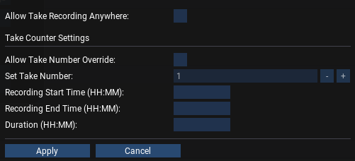

##### Allow Take Recording Anywhere

This setting overrides the default safety feature of only allowing new recorded items after the final item on the folder. This is useful if you record musical material out of order and wish to place new items at an arbitrary position on the project timeline.

##### Scheduled Recording

To start (and optionally end) a recording at specific times or manually start a recording to end at a certain time or after a certain duration, click the `Settings` button on the Record Panel window and add the appropriate entry or entries in HH:MM format. After pressing `Apply`, the Record Panel window will display information above the take number. If you enter a start or end time earlier or equal to the current time, the function will assume a next day schedule and will annotate the time with an asterisk (*). Likewise, with both a start and end time, if the end time is earlier than or equal to start, it will assume a time 24 hours later. Don't forget to arm your tracks before walking away!

##### Next Global Take Number

Only active when Global Take Numbers is enabled in `F5` preferences. Sets the number the next recorded take receives. It is independent of session take numbers and keeps counting across sessions.

##### Overriding Take Numbers

You shouldn't need to use this but there are cases where you might want to start a new ReaClassical project but continue from the previous day's last take number. To do so, check the "Allow Take Number Override" option and set a new take number. Note that it will not allow you to set a number lower than already used.

### Remote Recording via web interface

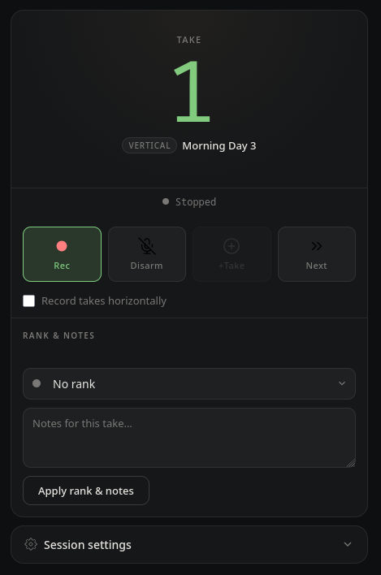

The ReaClassical Remote is a browser-based control panel that mirrors the Record Panel's core functionality, allowing you to arm tracks, start and stop recording, manage takes, and apply rankings and notes from a phone, tablet, or laptop anywhere in the room. To set it up, enable REAPER's built-in web remote by opening REAPER preferences `O` and navigate to Control/OSC/web and add a new web browser interface from the drop-down. Select `ReaClassical_remote.html` from the default interface drop-down and click apply. This same options page displays a ready-made access URL. Simply open that in a browser on any device connected to the same local network. Once connected, the Arm/Rec/Stop button, Pause/Disarm, +Take, and Next Section buttons all behave identically to their counterparts in the Record Panel window, and the take number display is kept in sync with the running panel. Session settings including start and end times, duration, and session name are read from REAPER on first load and can be edited and applied back to the running panel from the Session Settings section at the bottom of the page. Rank and notes can be set remotely and will be applied to the last recorded items exactly as if you had used the Record Panel directly. Note that the Record Panel Lua script must be open and running for the remote to function correctly, as it acts as the bridge between the web interface and ReaClassical's project state.

### Meterbridge

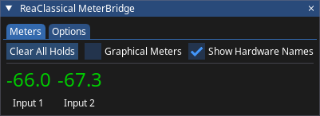

Use `B` to open the Meterbridge. The default view shows numeric peak holds. When tracks are record-armed, the main window displays recording inputs. During auditioning of material, the top rows show mixer tracks and the bottom any special tracks including RCMASTER and Master tracks. To switch to graphical meters, check the "Graphical Meters" option. Under the options tab, you can set color thresholds for yellow and red. To switch to channel numbers instead of hardware names, uncheck the option while tracks are rec-armed.

### Recording Indicator

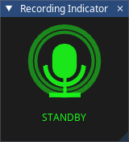

The recording indicator (`Alt+R`) is designed to be placed on a secondary monitor full screen so in situations where engineers are located in a separate control room, musicians are aware of when recording is active. Right-click to set custom colors for offline, standby, recording and pause.

### Live Bounce

To record the rough balanced mix as a stereo file at the same time as individual channels, add a live bounce track via Mission Control. Note that this is only available in a horizontal workflow given the necessity to record left-to-right on the time line to align with the folder recording.

### Listenback

To hear verbal feedback from a musician far away from the recording setup (for example, an organist in a loft), add a listenback track via Mission Control. Set the desired input channel via the dropdown. Monitoring will automatically mute during playback and recording. To set monitoring to always on, open the FX panel on the listenback track and set the dropdown in the monitoring JSFX to "Always On".

### Talkback

To talk to the musicians through a speaker in the studio, add a talkback track via Mission Control. Pick the producer's mic input from the dropdown in the Special Tracks section, then choose the speaker's output with `HW Outputs`. The talkback mic only goes to that output: it is not recorded, it is not in the mix, it never reaches your monitors or headphones and it ignores solo. It stays live during recording. The track is created muted; unmute it to talk using its mute button or **Toggle Talkback** (assign a shortcut or toolbar button in the Action List). Use the track fader to set the level.

### Splitting items into subtakes

To split a selected item into numbered subtakes, add generic markers via `M` at the desired locations and press `Shift+S` to split. To name a marker, press `Alt+M` (REAPER's insert and/or edit marker) and use the name instead of subtake numbering. `Ctrl+M` deletes the marker nearest the edit cursor, `Ctrl+Shift+M` moves the nearest marker to the edit cursor and `Ctrl+Shift+G` deletes all generic markers.

### Monitoring and Playback

- **Toggle Monitor** (`Ctrl+Shift+A`) cycles input monitoring on all the input tracks that are not disabled for recording: off, on, then tape mode. The new state is announced.
- **Toggle Playback** (`Ctrl+Alt+Shift+P`) mutes or unmutes the playback track (see Navigating a Project). The playback track is created muted, so this unmutes it for monitoring.
- **Take Number Display** (`Alt+T`) shows the current take number in a small window. It is started automatically by the Record Panel Daemon in the screen reader recording workflow, so that a sighted colleague can see the current take.

### Headroom

REAPER's peak indicators are reset automatically each time recording starts, so the peak values you see afterwards belong to the current take. Again, I refer you to the books on classical music production but in general I suggest aiming for around -12dB peaks on the meters. 24-bit recording allows for a lot of headroom so there's no need to push close to 0dB. Adjust the individual mixer track faders to balance. When using a 32-bit float device with dual AD converters as an interface (such as the Zoom F-series), ensure that the recording file format is switched to 32-bit float via project preferences `P`. The recorded levels might seem too low or too high during recording, but they can be easily adjusted afterward in ReaClassical without introducing any extra noise or distortion.

### Recording Safety

When using the Record Panel for recording (essential!), there is increased safety when using classical take recording via the automatic switch to a restricted set of keyboard shortcuts. In addition to using the record panel, you can also access various non-disruptive functions like zooming.

### Overdub Recording

To record additional material after the fact (say a separate narration track or an organ part in a church after the main recording session in a concert hall), edit the orchestral material as usual and use a mixdown as a guide track in a new project (or new project tab). To achieve this, use a vertical workflow (convert if necessary via Mission Control `C`), add a Reference track also via Mission Control and set the ReaClassical Project Preferences option `REF = Overdub Guide` to checked (`F5`). With this setting, audio on the guide track will be audible during take recording and auditioning of folders. Use Classical Take Recording via the Record Panel as normal. You can then S-D edit and mix the overdub material to fit with the orchestral mixdown or, if further mixing and mastering work is required on the original multi-track material, bring the organ part into that project as a new track in the folders (see below).

### Manipulating Tracks During a Recording Session

Screen reader users (Clara)

Use Accessible Track Setup to add, delete and reorder tracks (including aux and submix tracks) from the keyboard instead of Mission Control.

#### Disabling Channels

In a typical recording session, the musicians with the least to record are often allowed to leave the session early once their work is completed. If they were individually recorded using a spot microphone, it wouldn't make sense to continue recording on that channel. The ReaClassical way, both easy and visually obvious, is to open Mission Control `C` and check "Rec Disabled" for the particular channel(s). When arming and recording, these channels will now be excluded. This allows the user to maintain hardware connections that were originally set up with the ability to quickly bring the microphone back in as required.

#### Adding a New Microphone Mid-Recording Session

You can add a track to all folders in the project at once via Mission Control. It will prompt you for a name and then add a new track with that name to the end of each folder. This also works for a single folder while working in a horizontal workflow.

#### Deleting tracks

In both horizontal and vertical workflows, you can use Mission Control to quickly delete child tracks from all folders of the project.

#### Re-ordering tracks

In both horizontal and vertical workflows, you can re-order the mixer tracks by selecting the track in Mission Control and using the arrow buttons. This also moves all audio and assigned recording inputs. Aux and submix tracks can be moved up and down in the same way.

### Audio Calculator

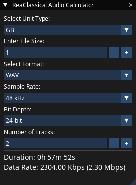

To figure out required disk space for a duration of audio or vice versa to figure out maximum duration of audio you can record based on available disk space, use `Shift+H` to open a calculator. You can set units, channel count, samplerate, bit depth and format (WAV or MP3 at various bitrates).

Screen reader users (Clara)

The Accessible Audio Calculator offers the same calculation as a keyboard-driven window.

- ← Previous
- ↑ Up
- Next →

## Importing

While it is always better to record in ReaClassical for traditional recording sessions, you may prefer using a portable recorder for live performances. Further, you might need to import audio recorded by other engineers who used a different DAW.

### Smart Import

Smart Import brings in audio files that follow a simple naming scheme, working out the track, take and (optionally) session from the filename. It handles both ordinary mono and stereo files and multi-channel files from portable recorders (see Multi-Channel Files from a Portable Recorder).

#### File Naming

The take number must be at the very end of the filename, just before the extension, preceded by an underscore. The "T" (for take) and any zero-padding are optional. The part of the name before the take number is split at underscores: the **last** part is the track name and anything before it is the session name. Examples (where x represents a digit):

- `sessionname_trackname_Txxx.wav`
- `sessionname_trackname_xxx.wav`
- `trackname_Txx.wav`
- `trackname_xxx.wav`

Examples of good filenaming include:

- `morning_cello_012.wav` (session "morning", track name will match "cello", take 12)
- `day1_morning_cello_012.wav` (session "day1_morning", track name will match "cello", take 12)
- `harpsichord_T4.flac` (no session name, track name will match "harpsichord", take 4)

Examples of bad filenaming include:

- `005.wav` (no track name)
- `violin56.wav` (no underscore before the take number)

WAV, FLAC and AIFF files are imported. A file named `roomtone.wav` is always ignored, as it is reserved for room tone.

#### Split Recordings

Many recorders split a long take into several files when it reaches the maximum file size. Smart Import joins these back into a single take if each file carries a four-digit **part number** after a "T"-style take number:

- `trackname_Txxx_xxxx.wav`
- `sessionname_trackname_Txxx_xxxx.wav`

For example, `piano_T003_0001.wav`, `piano_T003_0002.wav` and `piano_T003_0003.wav` become take 3 on the piano track. The parts are placed end to end with no gap and the fades where they meet are removed, so the take plays as one continuous recording.

The part number is only recognised after a take number with a "T". Without it, the last number is the take number as usual, so `piano_0002.wav` is still take 2.

- The parts don't have to start at `0001` (for example if part 1 is already in the project or has been deleted), but there can't be a missing part in the middle: parts 1 and 3 without part 2 are reported and that take is skipped
- Every track in a take must have the same number of parts

Important

Don't skip this renaming step if you want to import files easily from another DAW! Manual import by dragging in material can be time-consuming and may not allow you to use functions like searching by take number.

#### Importing

1. Ensure that you have first created a horizontal or vertical workflow ReaClassical project.
2. Copy or move source material into the media subfolder inside your ReaClassical project folder (you can also assign a custom import/recording path via Project Settings `P`). Subfolders are searched too.
3. Either leave the track names blank (**recommended**) or ensure that track names in the project match the track text in the filenames. If your filenames also contain a session name prior to the track name, the items will be grouped accordingly.
4. Via the top ReaClassical menu, click on `Project Management > Smart Import Audio` or use shortcut `Ctrl+Alt+Shift+I`.
5. Choose your options on the **Named Tracks** tab and press **Import**.
6. Open Mission Control to add special tracks such as aux & submix, make routing adjustments etc.

The Named Tracks tab shows the workflow of the project, how many new takes and sessions were found, and where the material will be inserted. Files already used in the project are ignored, so you can "smart" import further material into a non-empty ReaClassical project.

Material is inserted at the edit cursor. The import is built first and then, if anything already sits at or after the cursor on the folders being imported into, that material is moved later by exactly the length of the import to make room. Only the folders that actually receive imported items are affected: importing into the first source folder does not disturb the destination folder or untouched source folders. If an existing item straddles the cursor, it and everything after it move, and a one-second gap is left after the new material.

If the project's track names are all blank, you are first given the opportunity to set the order in which the captured track names are assigned to the mixer tracks by dragging rows into place.

**Import only these takes (optional)** lets you restrict an import to a session name and/or a list of takes such as `1-3,5,11-15`.

In a **horizontal** workflow all takes are laid out left to right in the single folder, one session after another.

In a **vertical** workflow, takes are placed in source folders. Choose the **Starting folder** (the first source folder to use) and a **Distribution Mode**:

- **One folder per take**: within each session, the first take goes in the starting folder, the second in the next folder down, and so on. New source folders are created if the project doesn't have enough. Each further session begins again at the starting folder, to the right of the previous one.
- **Use current folder count**: takes are dealt out in turn across all the source folders that already exist from the starting folder downward (take 1 to the first, take 2 to the second, ..., then back to the first folder, to the right of the first round). No folders are created.
- **Round-robin across custom number of folders**: the same dealing out, but across the number of folders you enter, creating folders if needed.

A preview shows the result, including a warning when new folders will be created. Takes made from split recordings are listed with their part count, for example "T003 (3 parts)".

**Gap between takes** sets the space left between consecutive takes in the same folder (2 seconds by default). Set it to 0 to place takes directly against each other; the fades where they touch are then removed. This is useful for recorders that split a long recording by starting a new take number rather than adding a part number. The setting is remembered for the project and has no effect in **One folder per take** mode. Split recording parts are always joined with no gap, whatever this is set to.

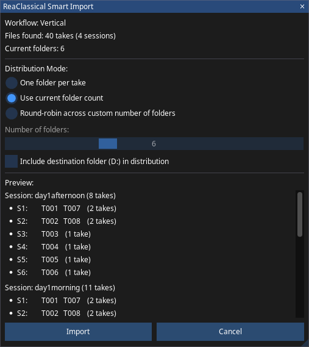

Screen reader users (Clara)

The same shortcut opens a keyboard-driven walkthrough, announced through Clara, with an explicit confirmation step before the import happens. If the media folder also contains multi-channel files, you are first asked to choose between **Import Takes** and **Import Polywav**.

### Multi-Channel Files from a Portable Recorder

If you use a portable recorder such as a MixPre, you might have a multi-channel combined file (a "polywav"). Smart Import can split these into a set of mono and stereo tracks. The **Polywav** tab appears in the Smart Import window whenever the media folder contains unused files with more than two channels.

The filenames must follow the take-number rule above, with an optional session name but no track name: `[sessionname_]Txxx.wav`. A hyphen can also separate the session name from a "T"-style take number (`sessionname-Txxx.wav`). Every polywav imported in one go must have the same number of channels.

Split recordings work here too, using the same four-digit part number (see Split Recordings): `[sessionname_]Txxx_xxxx.wav`. This matches the naming of Zoom recorders such as the F8n Pro (firmware 1.3 or later), so files such as `261024-T001_0001.WAV` to `261024-T001_0005.WAV` import as one continuous take 1 in session "261024" without renaming. A missing part in the middle or a duplicate take stops the polywav import, with the problem files listed.

Enter a **channel composition pattern** made of the digits 1 (mono) and 2 (stereo), read left to right across the channels of the file. For example:

- `2` makes the first stereo pair, and then every remaining pair of channels is also treated as stereo
- `21` makes a stereo pair followed by a mono channel; the remaining channels are mono
- `221` makes two stereo pairs followed by mono channels for everything else

Once the digits have been used up, the last digit repeats for as many whole groups as still fit, and anything left over becomes mono tracks. ReaClassical checks that the result fits before touching your project, then distributes the takes with the same options as Named Tracks.

The channel groups are placed on the tracks of the folder in order: the first group goes to the first track, the second to the second, and so on, so the project needs at least as many tracks per folder as there are groups. Tracks that already have names keep them, so you can set up your tracks first and the channels simply follow their order. Any blank tracks are named after their channels (for example "Ch 1" or "Ch 2-3 (Stereo)"). The Polywav tab works on its own, so a media folder that contains only multi-channel files is fine.

### Importing a DDP or PMI

ReaClassical can rebuild a full CD track and album metadata layout from an existing master, for checking or remastering. Use a fresh ReaClassical project whose destination folder is empty.

- `Project Management > Import DDP` (`Ctrl+Alt+Shift+D`): choose the DDP's raw audio stream, a file with a `.DAT` extension (conventionally `IMAGE.DAT`)
- `Project Management > Import PMI` (`Ctrl+Alt+Shift+M`): choose a Pyramix `.pmi` pre-master

### Manual Import by Dragging

1. In your source folder, select items that should be aligned vertically (for example, every channel for particular take) and drag into the ReaClassical project being sure to drop onto one of the folders created by ReaClassical with a track count that matches the number of files you selected. Choose the option "Same time position on separate tracks"
2. Continue as above for each take
3. Open Mission Control `C` to add special tracks such as aux & submix, make routing adjustments etc.
- ← Previous
- ↑ Up
- Next →

## Navigating a Project

In addition to built-in REAPER functions, ReaClassical uses a series of keyboard shortcuts to help you easily navigate your classical project. You can of course still navigate by clicking around with the mouse as you would in any REAPER project; the shortcuts are there to make it faster, and to make it possible without the mouse at all. Important: I always make some dedicated time post-recording to get an overview of the recorded material, tidy up the digital notes I took during the session and perform a backup on an external drive as soon as possible.

### Whole Project

Use `Ctrl+Alt+→` (or `Ctrl+Alt+←`) to see the whole project horizontally and/or `Ctrl+Alt+↓` (or `Ctrl+Alt+↑`) to see everything vertically. If you want to zoom both horizontally and vertically at the same time, use `` ` `` (backtick). REAPER's own `Home` and `End` keys take you to the start or end of the project. `+` and `-` zoom in and out horizontally.

### Tracks and Folders

The arrow keys move you around the project without the mouse. Each move selects the track and announces it (name, peak level and any mute or solo state):

- `↓` and `↑`: next and previous track within the current folder. In a project with a single track per folder these move between folders instead
- `Alt+↓` and `Alt+↑`: next and previous folder
- `D`: the first folder in the project

Moving to a folder makes it the folder you hear (the others are muted) and selects the item nearest the edit cursor. If a special track such as an aux, submix or reference is selected, `↓` and `↑` step through the visible special tracks instead. To jump straight to a track by name, press `Shift+J` and type part of its name.

### Finding Takes

Use `Enter` on the main keyboard or numpad to quickly search for a take based on the underlying filename of the media item. This will work for any file-naming system that uses numbers before the file extension such as `mainpair-T04.wav`, `cello-spot-take23.flac` or even `ortfpair(04).wav` such as created by Presonus Studio One. Note that if the imported or recorded files have zero-padding that is not a problem. If you have used an item to create an S-D edit, searching for a take will ignore these items and move directly to the original sources. In `F5` preferences, you can set to search by item name instead. In the ReaClassical Notes app `N`, you can override and reset take numbers. These take priority in the search.

With Global Take Numbers enabled, type `G` followed by the number (for example `G42`) to find a take by its global number instead, for instance when a video editor refers to camera clip 42. The session name is ignored for global numbers, since each one is unique across the project.

### Jump to Time

Press `J` to jump to a specific absolute or relative time using right-aligned logic, similar to video editing applications. Press `Ctrl+J` to do the same within the selected item or a set of consecutive crossfaded items, where an absolute time counts from the start of that selection. Prefix with + or - to make relative jumps from the current cursor position. Colons are ignored, so `1:23:45:10` and `01234510` are read the same way. Once you get the hang of using this input logic, moving to any position is extremely quick!

#### Some Right-Aligned Logic Examples

| Input | Meaning (based on project frame rate) |
| --- | --- |
| `100524` | Move to absolute position 10m 5s 24f |
| `1141711` | Move to absolute position 1h 14m 17s 11f |
| `+8` | Jump forward by 8 frames |
| `-1015` | Jump backward by 10s 15f |
| `+23000` | Jump forward by 2m 30s (and 0 frames) |

### Items & Markers

You can shuffle back and forth between item edges and fades by using `←` and `→` (or `Q` and `W`). While editing a crossfade these move through the crossfade, and with an envelope selected they move between its points. More precise item moves:

- `Alt+←` and `Alt+→`: start and end of the selected item
- `Ctrl+Shift+←` and `Ctrl+Shift+→`: first and last item on the track
- `Shift+Q` and `Shift+W`: start and end of the folder
- `Alt+Q` and `Alt+W`: previous and next group of crossfaded items

Move between markers by using the `,` and `.` keys (by design given on my keyboard they are the same keys that have `<` and `>`).

### Markers, Regions and Time Selection

- `M` adds a marker at the cursor and `Alt+M` inserts or edits a marker (to give it a name). `Ctrl+M` deletes the marker nearest the cursor, `Ctrl+Shift+M` moves the nearest marker to the cursor, `Ctrl+Shift+G` deletes all generic markers and `L` opens REAPER's region and marker manager. S-D markers use their own keys; see Editing
- `;` creates a region from each selected item, named after the active take, `:` creates a region from the time selection, and `Ctrl+Alt+R` deletes all regions
- `[` and `]` set the start and end of the time selection at the cursor, `Ctrl+]` and `Ctrl+[` move the cursor to the start and end of the time selection, and `/` sets the time selection to the selected items
- `0` deselects all items

### Parents & Children

ReaClassical can hide or show children of track folders. This means that editing multi-track classical music can be as easy as editing a stereo track. Making an edit to the parent track automatically makes the same one to all the children too. To show or hide the children, select the parent track and press `E`. The other benefit is that a whole set of takes can be displayed vertically in the main editing window without too much effort.

### Peaks Display

To adjust the visual zoom of wave peaks, use `Ctrl+↑` and `Ctrl+↓`. This is purely visual and allows for easier editing of quieter sections.

### ReaClassical S-D Editing Toolbar

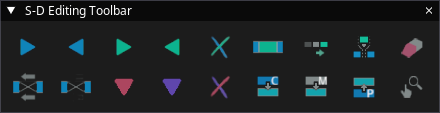

While I designed ReaClassical to be used efficiently with keyboard shortcuts, there is a custom S-D editing toolbar for those that prefer it. However I do highly recommend learning the key strokes as you will find your editing speeds improve dramatically. The floating toolbar can be opened via `F6` but will automatically open once when you start source-destination editing. Right-click to set a different icon layout and/or zoom. Hover over the icons to discover what is available.

### ReaClassical Top Menu

At the top of the arrange window, you will see a dedicated ReaClassical menu (in between `Options` and `Extensions`). While not intended to be used as the primary way of running ReaClassical functions, it is an organized way of discovering the individual available functions and learning the keyboard shortcuts.

Screen reader users (Clara)

Every navigation move above is announced, so no extra step is needed. Use `Shift+J` to go straight to a track by name, and `!` to hear the last announcement again. The announcement shortcuts for take number, timeline position and items in the folder are listed in Using ReaClassical with a Screen Reader.

### Summary of Track Types in ReaClassical

While some of these will be covered later in the manual, it is useful to give a summary of track types you can currently use in ReaClassical. First, we have the *regular* folder or folder of tracks shown in the arrange window. These are where you record or import takes. Second, we have the mixer tracks designated via `M:` prefix. These tracks shown only in the mixer are where you adjust the usual track controls such as names, pan, volume, phase, add FX etc. Their names are synced across the project via when added or renamed via Mission Control. Third, we have aux busses designated via `@` prefix. You can route mixer tracks to these to use as a reverb bus etc. Fourth, we have submix busses designated via `#` prefix. You can route mixer tracks to these as a way to collect together microphones from the same orchestral section etc. Fifth, we have a dedicated room tone track where you can place recorded or generated room tone (more on this in the mastering section). Sixth, we have the *RCMASTER* bus which leads directly to the master REAPER bus. Here you can gain stage into the master bus, add FX etc. Seventh, we have reference tracks which lie outside of the RCMASTER structure thereby allowing the user to quickly make comparisons with other imported material via the audition shortcuts. Next, there is the possibility of a live bounce track. This also lies outside of the RCMASTER structure and is a way to capture a live stereo mix from the RCMASTER track.

Note

Live bounce tracks are only available when recording in a horizontal workflow.

Next, another track outside of the RCMASTER structure is the listenback track. This is a way to monitor musicians, conductors, producers etc who might be far away and need to communicate with the recording engineer via a microphone channel. The talkback track does the reverse: it sends a producer's mic to a speaker in the studio, never reaches RCMASTER or your monitors, and stays live while recording. There is also a playback track (a maximum of one, shown in the mixer only, created muted) that you can send to a chosen pair of hardware outputs and unmute for monitoring with `Ctrl+Alt+Shift+P`. Finally, the master bus itself where again you can set final levels, add FX etc. As mentioned elsewhere, try not to delete the mixer tracks or RCMASTER. But, even if you do by accident, open Mission Control `C` to recreate them.

Important

A reminder to do all track management in Mission Control!

- ← Previous
- ↑ Up
- Next →

## Project Management

### Statistics

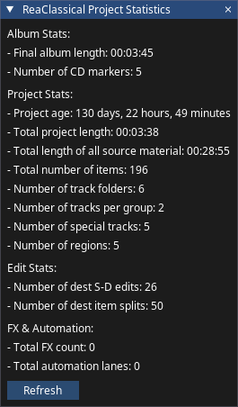

For a complete set of statistics on the ReaClassical project, either for your own information or to assist with billing a client, go to `ReaClassical > Utilities > Show Statistics` or use the shortcut `F1`. For example, you might have a billing system that charges clients based on number of source-destination edits, or mixing/mastering based on the final length of the album. Information includes:

- **Album**: final album length, number of CD markers, and the number of items and total length of material outside the album (anything on the first track after a gap of more than 60 seconds; see the tip at the start of the Mastering chapter)
- **Project**: project age, session time, total project length, total length of source material, total number of items, number of track folders, number of tracks per folder, number of *special* tracks and number of regions
- **Edits**: number of destination S-D edits and destination item splits
- **FX and automation**: total FX count and number of automation lanes

Session time is the elapsed time (in hours and minutes) since the project's session timer was started, and can be reset to zero from the statistics window. The window also shows your ReaClassical and REAPER versions. The statistics can be copied to the clipboard.

Screen reader users (Clara)

With Clara installed, `F1` opens Accessible Show Statistics, which lists the same values for you to step through and lets you reset the session timer.

### Typing Notes

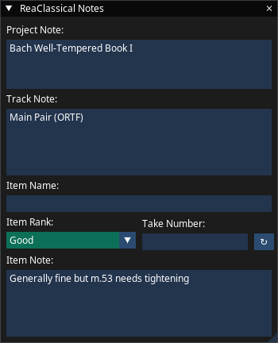

Add project, track and item notes using ReaClassical's Notes window (`N`, or `ReaClassical > Utilities > Add Project/Track/Item Notes`). For the selected item you can also set the item name, item rank and take number (with a button to reset it to the number found in the filename), as well as an item note. The take number you set here takes priority when finding takes.

Screen reader users (Clara)

`N` opens an accessible Notes window with the same fields. Use `Left`/`Right` (or `Q`/`W`) to move between items while it is open and `Space` to play and stop. Item Rank (`Ctrl+R`) and Item Name (`Shift+N`) also have their own quick windows.

### Manually Coloring Items

Use the Colorize function (`K`, or Colorize Selected Item(s) in the ReaClassical menu) to set a custom color (or remove it) for the selected items.

### Folder Structure

ReaClassical defaults to placing recorded media in a `media` subfolder and exports in an `Exports` subfolder of the project folder, making project file navigation easier.

### Automatic Backups

REAPER allows for powerful and complex backup routines. ReaClassical sets REAPER's auto-save to every 15 minutes and keeps a limited number of backups. Review and modify these in REAPER's Preferences under Project > Backups to suit your own way of working, including switching to backups and auto saves for a number of unique days.

### Folders and Items

- **Duplicate folder (No items)** (`Ctrl+D`) adds a copy of the selected folder's tracks as a new folder, without its items. From a horizontal workflow it first asks whether to convert to a vertical workflow
- **Delete Source Folder** (`Shift+D`) deletes the selected source folder (vertical workflow only; it asks you to confirm)
- **Delete All Source Items** (`Ctrl+Alt+Shift+Delete`) deletes every item in every source folder (vertical workflow only; it asks you to confirm)
- **Select All Items in Folder** (`Ctrl+Alt+A`) selects every item in the folder of the selected track
- **Paste** (`Ctrl+V`) pastes items and announces how many were pasted
- **Remove All Item Fades** (`Shift+F`) removes the fades from items whose edges are not part of a crossfade, leaving crossfades intact

### Project Tabs

`Ctrl+Alt+N` opens a new project tab and `Ctrl+Tab` (or `NumPad +`) switches to the next one. Switching announces the name of the project you land on. Multiple project tabs are the way to make multi-disc albums and to compile edits from several projects; see Multi-Project Tab S-D Editing.

### Cleaning

If in doubt, keep everything! Otherwise, the `File > Clean current project directory` is an excellent way to reduce the size of your projects. Note that when assigning a session name via the Record Panel Window, currently the above REAPER menu item doesn't search recursively. In a way, this reduces the chances of accidentally deleting precious takes. You can always manually delete but, from experience, it is *much* better to simply keep everything.

### Archiving

There are various ways to archive classical music projects. First, you can access the Project Bay by `Ctrl+B` shortcut. You can then ensure that all media used in the project is contained within the project folder itself. If not, you can select as many as necessary, right click and move/copy into the project folder. After this, you can simply compress the folder as a zip and store on an external drive. A further step to guaranteeing ability to open in the future is to freeze tracks so that plugin effects are baked in (with ability to unfreeze later if possible). Alternatively you can save a copy of the project via `File > Save project as...`, converting to a format like FLAC and trimming the media as you wish. Finally, one to look out for in the future is [Project Archiver](https://forum.cockos.com/showthread.php?t=280150). However, I don't believe it is quite ready for prime-time yet and recommend using one of the other methods for now.

- ← Previous
- ↑ Up
- Next →

## Auditioning

### Auditioning Folders

Audition your material via mouse hover + `A` on parent or child tracks. The folder under the mouse becomes the one you hear (the others are muted), any record-armed tracks are disarmed, and playback starts from the mouse position. Use hover + `Shift+A` to play back at a custom rate set via ReaClassical Preferences `F5` (default x0.75). Use mixer mute and solo buttons to further customize what you hear. Hover over a reference track for easy A/Bing between your audio production and one or more reference audio files.

Tip

To quickly remove all record-arming in the project, use mouse hover + `A` or close the Record Panel.

### Choosing the Folder from the Keyboard

You do not need the mouse to choose which folder you hear. Moving to a folder with `Alt+↓`, `Alt+↑` or `D` (see Navigating a Project) makes it the audible folder, and `Space` plays and stops. `Shift+Space` plays and stops while moving the edit cursor with the playhead, and `Ctrl+Shift+Space` returns to the position where you last stopped.

### Auditioning Around S-D Markers

Once you have set source and destination markers, you can hear them without moving the cursor. Each shortcut selects the relevant folder, makes it audible and plays a short segment:

| Shortcut | Plays |
| --- | --- |
| `6` / `8` | 3 seconds from the destination IN / OUT marker |
| `7` / `9` | 3 seconds from the source IN / OUT marker |
| `Ctrl+6` / `Ctrl+8` | the 3 seconds up to the destination IN / OUT marker |
| `Ctrl+7` / `Ctrl+9` | the 3 seconds up to the source IN / OUT marker |
| `Alt+6` or `Alt+8` | from the destination IN marker to the destination OUT marker |
| `Alt+7` or `Alt+9` | from the source IN marker to the source OUT marker |

If a required marker is missing, ReaClassical says so. Starting a new audition stops any audition still playing. To compare takes before choosing source markers, see the Source Audition Manager (`Z`) in the Editing chapter.

Screen reader users (Clara)

All of these work with the keyboard alone and announce what they are doing, including a message when a marker is missing or when the OUT marker is not after the IN marker.

- ← Previous
- ↑ Up
- Next →

## Editing

Source-destination editing is truly anywhere to anywhere. This means you can place your source and destination marker pairs on *any* folder.

### Editing Step-by-Step

Ensure that the folder where you want to place the marker pair is selected. The best way to do this is to click on the item where you want the marker. Note that in `F5` preferences you can set placement at mouse hover meaning that the desired folder is chosen based on hover position.

1. Set destination IN and OUT markers via `1` and `2`
2. Set source IN and OUT markers via `3` and `4`
3. Press `5` to make the source-destination edit (2-, 3- or 4-point edit depending on how many markers you set), or `F4` to make a time-stretched S-D edit (Replace with timestretching, requires all 4 markers), or if only using destination IN marker and both source markers, `F3` for an "assembly" or 3-point "insert" edit
4. To finesse the edit, click on the right item of a crossfade pair and press `F`

Screen reader users (Clara)

Every marker and edit action announces what it did. If you place a marker on the wrong side of its partner (a source OUT before the existing source IN, for example), ReaClassical deletes the stale marker and says so, so an edit can never silently take far more material than you intended. Use `Ctrl+1` to `Ctrl+4` to move to each marker and the audition keys described in Auditioning to hear them. For crossfades, see Crossfade Editing for Screen Reader Users.

### Coloring and Fixing Takes

There is no separate "prepare takes" step before editing any more. ReaClassical's editing functions find the matching items on the other tracks of a folder by midpoint matching rather than relying on explicit group IDs, and empty items are cleared out automatically each time Mission Control opens.

- **Auto-color project** (`Shift+K`) colors items by take number or folder. ReaClassical runs it for you at the points where it is needed; run it yourself after importing material by hand. Set **No Auto Item Coloring** in the `F5` preferences to switch it off.
- **Fix Crossfade Sequence Edits** (`Shift+X`) repairs items that should be grouped but have become misaligned across the tracks of a folder, for example because ripple-per-track was switched off by accident while dragging items. Select any one of them, run it and choose which track has the correct edits. Every other track in the folder is rebuilt across that group from the reference track's edits, re-pointed at each track's own audio file for the same take number.

### Crossfade Editor

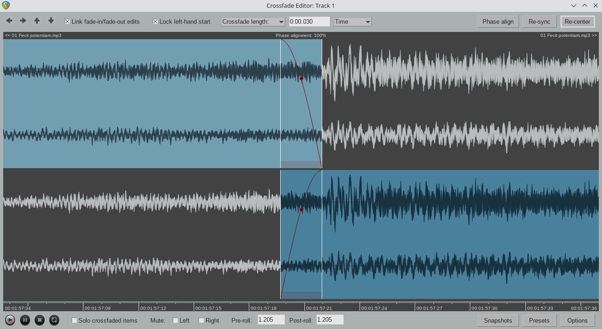

Since v7.40, REAPER includes an excellent professional two-lane crossfade editor similar in nature to the specialist classical DAWs such as Sequoia and Pyramix. With the improved crossfade editor, users can see the continued "ghost" waveforms of the items beyond the crossfade they enter and likewise the previous waveforms of the items that exit the crossfade. The ability to visually align transients and then position the crossfade just before it is absolutely critical (and fun when you have the tools to do it!). Select the right-hand item of a fade (or hover over the item if **Add S-D Markers at Mouse Hover** is set in the `F5` preferences) and press `F` to enter crossfade editor mode. Press `F` again to leave it. The two-lane editor has its own keyboard shortcuts for auditioning and navigating. To audition material, hover the mouse inside the crossfade window and:

- Press `A` to audition the crossfade with mirrored pre/post roll based on mouse cursor location
- Press `S` to audition just the left item based on mouse cursor location or its mirrored position
- Press `D` to audition just the right item based on mouse cursor location or its mirrored position

Use `Shift+A`, `Shift+S` or `Shift+D` to do the equivalent but with a custom playrate as set in `F5` preferences. Other shortcuts include:

- Press `E` to audition just the top lane based on mouse cursor location or its mirrored position
- Press `C` to audition just the bottom lane based on mouse cursor location or its mirrored position
- Press `Alt+S` to audition just the out-of-bounds material left of the xfade
- Press `Alt+D` to audition just the out-of-bounds material right of the xfade

You can shuttle between crossfades using the `Q` and `W` shortcuts (or `←` and `→`). Please see the REAPER manual for more details of what is possible including phase alignment and various view options.

#### Crossfade Editing for Screen Reader Users

Screen reader users (Clara)

REAPER's two-lane crossfade editor depends on seeing and dragging the waveforms, so it is not usable with a screen reader. With Clara installed, `F` starts a keyboard-driven **crossfade mode** instead, which gives you the same control over the crossfade: nothing is lost. See Crossfade Mode for all of its keys.

### Source Audition Manager

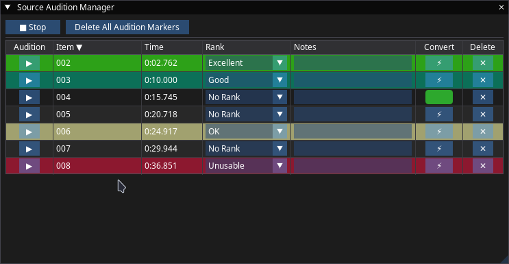

When making a source-destination edit, you may not have a list or annotated score from the musicians or producer showing preferred edits. If the decision is left to the audio engineer, this process is very straightforward. First set the source audition mode to checked in `F5` preferences. Then, open the Source Audition Manager via the **Source Audition** button in Mission Control or the `Z` shortcut. To set up all the source audition pairs, set multiple sets of source in and out markers. You will note that when you start to add a second pair, the source markers are transformed into a take marker "region". The only limitation is that you can only have a single take marker region set per item. This allows the user to quickly reposition the S-D markers by simply setting new ones. If your recorded items each contain multiple passes of the same musical material, consider splitting them via the `S` shortcut. Use the controls in the window to audition, rank and add notes. Once you have settled on a best take, press the convert button (or place edit cursor within a take marker region and press `Alt+Z`). Note, that any existing real source pair is converted to a take marker region. Assuming one or more destination markers are already set, you can press `5`, `F3` or `F4` to make the desired edit. Sometimes the suitability of source material is difficult to judge until it is heard with the surrounding destination material. Given that all source markers are stored as take marker regions if inactive, it allows the user to quickly undo an edit and switch to an alternative pair. During auditioning, you can delete individual pairs via the `X` on the specific table row, as well as delete all source audition markers by clicking `Delete All Audition Markers` or pressing `Alt+Delete`.

#### Exporting Auditions

To send the candidate passages to the musicians or producer so they can choose, open **Export auditions** at the top of the Source Audition Manager. Set the sample rate, bit depth and dither (used for WAV and FLAC), and choose which auditions to include from their rank: **All auditions**, **Ranked only**, **Excellent only**, **Very Good or better**, **Good or better** or **OK or better**. The count next to the list shows how many auditions match. **Pre/post-roll** (0 to 10 seconds, 2 by default) adds context before and after each audition, but never goes past the edges of the take. Then click WAV, FLAC, Opus 160 or MP3 320. Each audition is rendered through the mixer to the master. In the vertical workflow, its folder is soloed while it renders. The files go into a subfolder of `Exports/Auditions` named for the format and settings. Each file is named after the take, followed by the audition's start time (for example `03m25s`) and any notes. Rankings are left out of filenames unless you check **Include take ranking in filenames**. All these settings are remembered.

### Other Editing Tips

#### Making a Crossfade by Hand

If two items on a parent track overlap, place the edit cursor somewhere within the overlap and press `X` to crossfade them. The crossfade uses the **S-D Crossfade Length** from the `F5` preferences (35 ms by default) and is applied to every track in the folder. You can then refine it in the crossfade editor with `F`.

#### Fading To or From the Edit Cursor

To fade a take in so that it reaches full level at a chosen point, select the parent item, place the edit cursor inside it and press `Ctrl+Shift+I` (**Fade In To Cursor**). Enter a fade length in seconds (2 by default). ReaClassical trims the item's left edge to that distance before the cursor and fades in from the new edge to the cursor. `Ctrl+Shift+O` (**Fade Out From Cursor**) works the other way round (3 seconds by default): the fade starts at the cursor, and the right edge is trimmed to where the fade ends. Both apply to every track in the folder. If there is less audio before (or after) the cursor than the length you asked for, the fade is shortened to fit. An edge that is already crossfaded is left alone; use the crossfade editor (`F`) for those.

Screen reader users (Clara)

Both functions announce the item, the fade length and where it starts or reaches full level, and say if the fade had to be shortened.

#### Healing Edits

Select any S-D edit and press `Ctrl+H` to heal it, restoring the material the edit replaced. This works for every kind of S-D edit (3-point insert, 4-point, and 4-point with timestretching), including edits where the material either side of the edit comes from different takes. ReaClassical saves the underlying material at the moment you make the edit, so there is no need for the surrounding items to match.

If the edit is made up of several items (for example because the source section spans more than one source item), selecting any one of them heals the whole edit.

Tip

This works at any point in the editing process and isn't restricted to the last edit made.

Note

Edits made with earlier versions of ReaClassical have no saved material. These can still be healed only when the items either side of the edit come from the same source file, with the later item further along in that file (for example, a patch over the top of a single best take). If an edit has since been changed in a way that no longer matches what was saved (such as splitting one of its items), ReaClassical falls back to the same rule. Healing an edit that has another edit directly alongside it is best done in reverse order: heal the most recent edit first.

#### Finding Source Material

The items representing a S-D edit are colored according to the source material. However, you can also easily locate source material by clicking on an edited item and pressing `Ctrl+F`. A color-coordinated source IN and OUT marker pair are placed at the source location and in vertical workflow mode, the associated folder is selected. This function also works across multiple project tabs.

#### Set Item Playrate with Ripple

This function, run via `Shift+R`, allows you to change the playback rate of a selected item, automatically rippling all subsequent items within the same folder to maintain the integrity of your edits. Select a single item on the folder track, enter a percentage value in the input box, and press `Apply & Ripple`. In relative mode (the default), the value is applied as a percentage change relative to the item's current rate — so entering `5` makes the item 5% faster than it currently is, while `-5` makes it 5% slower. In absolute mode (enable the "Absolute rate" checkbox), the value is always relative to normal speed — so `5` always results in a rate of 1.05x regardless of the item's current rate, and `0` always restores normal speed. The `Reset to Normal Speed` button is a convenient shortcut to return the item to 1.0x playback rate. Pitch is always preserved during time-stretching. Note that only one item may be selected at a time, as each item requires its own independent ripple calculation. The window also includes a Pitch Adjustment section for correcting intonation without affecting item length or requiring any ripple. Enter a value in semitones and press `Apply Pitch` — positive values raise the pitch, negative values lower it, and fractional values are supported for fine adjustments (e.g. `0.5` for a quarter-tone). The `Reset Pitch` button returns the pitch to `0.0` (no adjustment).

Screen reader users (Clara)

With Clara installed, `Shift+R` opens the accessible Playback Rate window, a keyboard walkthrough that makes the same rate and pitch changes with the same rippling. Press `H` in it for examples that fit the current relative or absolute mode.

#### Automatic Crossfade Protection

When performing S-D edits, deletions or ripple deletes, ReaClassical automatically detects any existing crossfades that straddle your marker boundaries and consumes them as part of the resulting edit. This prevents stray partial fades being left behind in your project. This is also useful when quickly iterating through alternative source material: since destination markers persist after an edit and are placed at the exact edit bounds, you can create new source markers and immediately re-edit without worrying about crossfade debris accumulating at the destination boundaries.

#### Marking Edits on your Scores

This is best done using a physical, photocopied score by the conductor or lead musician. I advocate for a “T” system where a large T is inserted into the score at the intended edit point. Either side of the T stem, and under the crossbar, the outgoing and incoming take numbers are written. A wavy crossbar indicates some leeway for where the edit point can be placed. Further notes can be attached underneath the T such as directions for tightening the gap etc.

[figure not shown]

#### Multi-Project Tab S-D Editing

If you'd like to S-D edit between various open project tabs you can set both the source and destination *project* markers via `Ctrl+Alt+1` (or `Ctrl+Alt+2`) for destination and `Ctrl+Alt+3` (or `Ctrl+Alt+4`) for source (essentially the same numbers associated with regular S-D markers). The markers can exist anywhere on the tab's timeline but perhaps the very beginning or end would be good to keep them out of the way. The S-D editing itself then works just as for a single tab other than any source markers that are set are not deleted to aid quickly undoing in the destination tab and being ready to reapply the edit. The only rule when using S-D project markers is to ensure that source or destination markers should be paired with the corresponding source or destination project marker. This workflow would, for example, allow you to have multiple project tabs (perhaps one for each symphony movement plus a final *destination* tab), allowing for both internal editing per tab but after setting the S-D project markers compiling the final edit in the *destination* tab. To delete all the S-D project markers press `Shift+Delete`. Also, in multi-tab S-D editing, when regular markers are placed, any other existing versions in other tabs are automatically deleted to ensure that only one version of the marker exists at a time across all open project tabs.

To set up a pair of tabs in one step, save your recording project and run **Set Up Dual Tab Workflow** (`Ctrl+Alt+5`). It adds the source project marker to the current project and saves it, then creates a copy under a name you choose (default: the project name plus "_destination") in the same folder. The copy opens in a new tab, with all items, markers and regions removed and the destination project marker added, and is saved. The new destination project keeps all tracks, routing and mixer settings, so you can start S-D editing into it straight away.

#### Playing Back Edits Automatically

To review each edit as soon as you make it, enable **Play Edit After Making It** in `F5` preferences. After `5`, `F3` or `F4`, playback starts shortly before the edit point (3 seconds by default, set with **Edit Playback Pre-roll**) and continues until you stop it, so you can check the crossfades right away. On the first edit of a piece, where there is nothing in the destination before the edit point, playback starts at the edit point itself. In dual-tab editing, playback always happens in the destination tab, and the setting is taken from the destination project.

#### Delete / Delete with Ripple

While perhaps not used as often as 3- and 4-point edits, I have created two functions for deletion of material. Delete & Ripple `Backspace` will delete the material between source IN and OUT markers and ripple material to the right backwards with a short crossfade. Delete Leaving Silence `Ctrl+Backspace` will also delete but maintain the silence without rippling backwards.

#### Copy/Move Destination Material to Source

Run either the copy `Ctrl+Alt+C` or move `Ctrl+Alt+M` version of the function from the S-D editing toolbar (no need to ensure the first track is selected) and the function will copy or move all items and edits from the destination folder directly below to a newly created source folder. This allows for saving versions of finished edits either via iteration (*copying* so you can continue to make further edits) or fresh (*moving* so you can compile an alternate version of a best take from scratch). These different edits can then be easily auditioned via `A` the shortcut. This is similar to a Pyramix-style iterative editing method while still maintaining the destination folder as the uppermost folder.

#### Promote Source to Destination

Select a source folder and press the "promote" icon in the S-D editing toolbar or `Ctrl+Alt+P` to promote the source folder to the top "destination" position.

#### Add S-D Markers to Edges of Item(s) or Time Selection

Used in combination with Delete / Delete with Ripple (`Ctrl+Backspace`/`Backspace`), you can quickly set both source markers to the edges of one or more selected items on a parent track or time selection via `F12`. This is a time-saver when dealing with potential *sliver* edits i.e. small unneeded leftover edits as a result of multiple rounds of zoomed-out S-D editing. Note that the built-in checks when manually placing destination markers should go some way to alleviating this issue which can easily go unnoticed in other classical music DAWs. Likewise you can use `Ctrl+F12` to set destination markers (selected items must be in the destination folder). Note that if using time selection for placing source markers, as for S-D marker placement via `3` or `4`, make sure you first have the desired source folder track selected before pressing the shortcut (a good way to do this is to first click on the item involved). You may prefer to set both source and destination markers this way over the more traditional number key shortcuts acting as a sort of hybrid between S-D and razor editing. Also note that if both selected items and a time selection exist, the time selection takes precedence.

#### Nudging Markers and Items

After auditioning a marker, nudge it with `Ctrl+,` (left) and `Ctrl+.` (right). Selected items are nudged with `Alt+,` and `Alt+.`. Both move by the project nudge amount, which you set with the Terminal command `nudge=10` (milliseconds) or under Other Settings in Accessible Preferences. The same keys with the "x modifier" (`Ctrl+Alt+,` and `Ctrl+Alt+.` for markers, `Alt+<` and `Alt+>` for items) move by the nudge amount multiplied by the modifier amount (Terminal `mod=10`). Each nudge is announced with the item name and the distance moved. While a crossfade is being edited in crossfade mode, use the crossfade mode nudge keys instead.

#### Move / Zoom to S-D markers

To move to any existing S-D markers use `Ctrl+1`, `Ctrl+2`, `Ctrl+3` or `Ctrl+4`. To zoom to any of the S-D markers for more fine-grained placement, use `Alt+1`, `Alt+2`, `Alt+3` or `Alt+4`. If you have multi-tab S-D editing set up, these shortcuts will also automatically move focus to the correct project tab.

#### Delete S-D markers

To delete all regular S-D markers, press `Ctrl+Delete`.

#### Floating Destination Folder

The floating destination folder feature enhances vertical workflow efficiency by dynamically positioning the destination folder just above the selected source folder. This reduces unnecessary vertical scrolling when setting IN and OUT markers for destination and source folders that are far apart in the project. Additionally, this feature is fully compatible with mouse hover S-D editing and when setting source markers to item edges (`F12`). To enable the floating destination folder, open ReaClassical Project Preferences (`F5`) and set the corresponding line to checked. For example, with floating destination enabled, place a source IN marker (via `3`) on any source folder. The destination folder will reposition itself just above the selected source folder. Add the remaining S-D markers as required. Perform any S-D edits via `5`, `F4`, or `F3`. Select another source parent and place another marker (`3`). The destination folder will continue adjusting dynamically. It is worth noting that if the destination folder moves above a source folder, the source marker track number correctly updates to reflect the new order. To disable floating mode, re-open ReaClassical Project Preferences and set `Floating Destination Folder` unchecked. This will also automatically move the destination folder back to the top of the project.

#### Razor Editing

Because of the potential for visual overlap of markers, I much prefer the REAPER razor edit functionality for vertical take work. It works a lot like the process shown in this Pyramix [video](https://www.youtube.com/watch?v=wQXwnvITQCQ). While Pyramix also has additional source-destination marker workflows, I couldn't help but feel that for professional ensembles that manage a high degree of tempo regularity between takes, this method can be extremely efficient. This isn't the document to introduce REAPER razor edits as there are plenty of resources online if you do a simple search. Here we are only concerning ourselves with creation of the razor area across all our pairs and spot mics (REAPER's default shortcut is the rather uninspiring Alt+Right drag). Thankfully, it can become the default editing mode by selecting the razor edit mode on the main toolbar and left-click dragging.

- ← Previous
- ↑ Up
- Next →

## Mixing

### Mixing Scenes

1. Add FX, change routing, and optionally adjust volume, panning etc via Mission Control `C`
2. Open Mixer Snapshot Manager via `Shift+M`
3. Create automatically-recalled mixer snapshots tied to items.
4. Before rendering, convert to real automation lanes via `Convert to Automation`

Note

If setting a snapshot tied to an unnamed item, the first part of the item's ID will be used as the identifier in the table row.

### Mixer Snapshot Manager in Detail

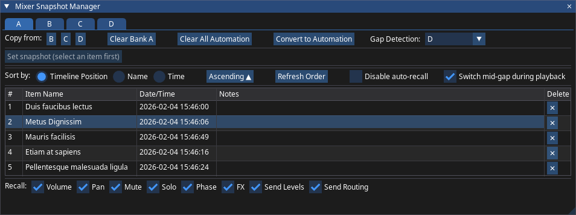

#### General Workflow

1. Click on an item that you want to be the start of a snapshot or mixer "scene"
2. Adjust any mixer parameter including fader, mute/solo, pan, FX parameters etc
3. Click `Set Snapshot...`.
4. To make changes, select the item or table row, tweak parameters and click the same button now re-labeled `Update Snapshot...`

Snapshots can only be set on items on the first (destination) folder track, which is the track that recall and gap detection are based on.

Important

Auto recall runs while the Mixer Snapshot Manager is open. To keep it running after you close the window, check **Background auto-recall**, which hands recall over to a background process. Once converted to real automation points, auto recall is disabled by design and the window can be closed.

Screen reader users (Clara)

Select an item on the first folder and press `Ctrl+Alt+Shift+S` (Snapshot Add) to capture a snapshot, or press `Shift+M`, which opens the accessible Snapshot Settings in place of the Mixer Snapshot Manager.

#### Copying and Clearing Banks

The Mixer Snapshot Manager allows 4 independent banks of snapshots with ability to copy between banks and clear.

#### Rendering

The snapshot manager window relies on real time playback for auto recall. For faster-than-realtime rendering, this will lead to unpredictable results. Therefore, at render time, it is advisable to convert to real automation data. To do so, press `Convert to Automation` and optionally set which folder to use for gap detection (the conversion will also respect the switching mid-gap checkbox). Mixer, aux and submix tracks with snapshot data will appear in the arrange window along with any active automation envelopes. If items connected to mixer snapshots are moved on the timeline as part of editing, click on the convert button again to get instantly updated automation data. To clear the snapshot automation and return to auto recall via the window while editing and mixing, press `Clear All Automation`. Automation items that you created by hand on mixer, aux and submix tracks are protected: converting and clearing only replace the automation that the snapshots created.

### Volume Automation

1. Ensure that a "Destination" or "Source" track is selected.
2. Make a time selection over the passage you want to change and press `I`. A time selection is required: changes that run from the cursor to the end of the piece are made with the Mixer Snapshot Manager instead.
3. Set the volume level and optional ramp in/out lengths and click `Apply Automation`. The ramps lie outside the time selection: ramp in is the time before the selection and ramp out the time after it.

While you dial in the level you hear it immediately on playback; ramps cannot be previewed in this way. Check **Keep window open after applying** to make several adjustments in a row.

The first time you create an automation item, ReaClassical engages **automation mode**: items on the source folders are locked and ripple editing is set to all tracks, so a ripple edit on the destination folder carries the automation along with it. In horizontal workflow nothing is locked; only ripple editing changes. You can switch automation mode on and off yourself with `Shift+I`, from the ReaClassical menu or with the **A** button on the main toolbar (it replaces the marquee selection button). The button lights up and animates while automation mode is on.

### More Advanced Automation

Turn on advanced mode to gain access to all envelopes associated with the track including FX parameters. If you also need to automate various aspects of the mixer tracks or special tracks, first make them visible in the track control panel by checking the box on the desired track row in Mission Control. Use `I` as before.

### Editing Automation Items

Select an automation item and press `Ctrl+I` (or right-click on it) to edit its middle value and optional ramp in and out values. You can adjust the positioning by left-click dragging on the item itself. Adjust the middle value length by alt/opt-click dragging on automation item edges. `Alt+D` and `Alt+E` show and hide automation lanes, `Shift+←` and `Shift+→` move between automation items and `Ctrl+Shift+↑` and `Ctrl+Shift+↓` move between envelope lanes.

Screen reader users (Clara)

Insert Automation (`I`) and Edit Automation (`Ctrl+I`) open keyboard-driven windows, the Automation Navigator and Accessible Edit Automation, in which you move between tracks, envelopes and values, and hear the level you are choosing while you dial it in.

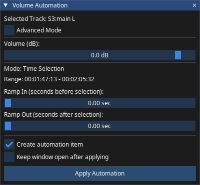

### General Mixing Workflow Suggestions

- Set piece-by-piece "scenes" using the Mixer Snapshots Manager adjusting mixer tracks, aux and submix controls and any FX parameters.
- Make temporary adjustments (for example, volume of spot microphones etc) via the automation function `I` on tracks with items.
- For spot microphones that should be mostly muted: 1. Use a time selection + `I` to reduce to lowest value (-150dB/-inf) for the whole piece or use edit cursor + `I` at the beginning of the timeline to affect the whole project. 2. Use further time selections + `I` to set required values and any ramping in and out.

Tip

Remember that the mixer tracks (the ones starting "M:") are fed by the destination and source folders you see in the arrange window. In other words, any automation you add to destination or source tracks will be filtered through the mixer track state. As an example, if your violin spot microphone channel is set at -5dB via automation but the violin spot mixer track fader is at -40dB, the actual output will be -45dB.

### Mixing for Dolby Atmos Using Fiedler Plugins

If you have the Fiedler Beam plugin on your system, use the Mission Control `Enable Atmos` that appears to add RCFader plugins and Fiedler Beam plugins to every Mixer track as necessary. This will also pass the current mixer fader values to the RCFader plugin. Subsequent presses of the button will check presence of RCFader and Fiedler plugins, and relative position between them, and synchronize fader values. Use `Disable Atmos` to deactivate both RCFader and Fiedler Beam plugins on every mixer track.

### Mixing with Outboard Gear

Use the Mission Control `HW Outputs` to set direct connections to hardware either automatically or manually. If you do not need connections to RCMASTER, disable using the dedicated button in the main Mission Control window. `Ctrl+Alt+Shift+T` toggles the mute on RCMASTER's own hardware output sends (it mutes all of them if any is unmuted, and unmutes only when all are muted), and `Alt+K` is Panic Mute, which silences everything that can reach your hardware outputs.

### Solo-safe RCMASTER outputs

Normally, soloing a track changes everything after RCMASTER: its hardware outputs, the live bounce and the master. To send a full mix to another destination (for example a video team's vision mixer) while you solo freely on your speakers and headphones, tick **Solo-safe RCMASTER outputs** in `HW Outputs` and route RCMASTER to that destination's outputs there. Your monitors should be fed from the REAPER master's hardware outputs.

With the option on, ReaClassical's solo controls (the Mission Control solo buttons, the mixer solo shortcuts, the Terminal and accessible solo commands, and mixer snapshots) only change what reaches the REAPER master. Soloed tracks go straight to the master, and RCMASTER is taken off the master while anything is soloed. RCMASTER's hardware outputs and the live bounce always carry the full mix. Turning the option on or off converts any existing solos.

Things to be aware of:

- Soloed tracks bypass any FX on RCMASTER, like an after-fader solo on a console.
- REAPER's own solo buttons in the mixer and track panel still use REAPER's solo, which affects every output. Use ReaClassical's solo controls instead.
- Folder solos while auditioning and editing still use REAPER's solo.

Each special-track output in `HW Outputs` has a trim next to it. Drag it, Ctrl+click it to type a value, or right-click it for presets. For example, -11.8 dB matches a +4 dBu interface output to a -10 dBV input such as a Blackmagic ATEM.

- ← Previous
- ↑ Up
- Next →

## Mastering

Mastering in ReaClassical is game-changing. Many features described here are not available in any other classical DAW. I hope that the *ReaClassical* way saves you much time and helps you look forward to the mastering phase of the project. While automatic DDP generation, automatic room tone function, and professional album reports are the main features here, you will probably find the revolutionary mixer snapshot manager is an extremely efficient way to add auto-recall mixer scenes across your production as well enjoying the ability to quickly reorder album tracks via a simple keyboard shortcuts.

Tip

ReaClassical treats the album as the items on the first track of the first folder, up to the first gap of **more than 60 seconds** between the end of one item and the start of the next. Everything after that gap is left out of the CD track markers, the album length and the album report. A gap of 60 seconds or less keeps the later material in the album. If working in horizontal workflow, ensure that there is more than 60 seconds of empty timeline between the end of the proposed album and any other source material. Instead, you can also choose to convert to a vertical workflow via Mission Control `C`, where source material lives in other folders. Show Statistics `F1` reports how many items, and how much material, lie outside the album.

### Basic Mastering Workflow

1. The album is built on the first (destination) folder, so make sure your finished edit is there
2. Remove all names from items on the parent track aside from those you want to be track starts. You can clear all items on the folder track via `Ctrl+T`
3. Enter track start names via the Notes window `N`
4. Press `Y` to open the metadata editor
5. Once happy, use the **Render** buttons along the bottom of the metadata editor (see Rendering).

Note

In order to make the process as streamlined as possible for the user before the metadata editor window opens, on first run generic albumwide metadata (the name starts with "@") is added to an unnamed item on the parent folder. If that is not possible, a transparent split is made on the final item of the album.

### Metadata Editor in Detail

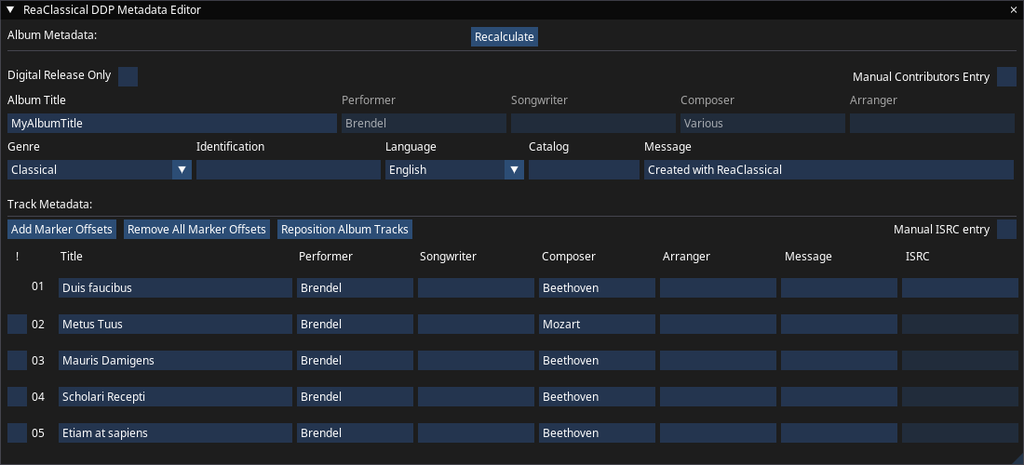

The metadata window allows you to enter all track and album metadata in a single place.

- **Album metadata**: title, performer, songwriter, composer, arranger, genre, identification, language, catalog (EAN/UPC) and message
- **Track metadata**: title, performer, songwriter, composer, arranger, message and ISRC for each CD track

ISRC values are filled in automatically from the first track's entry, and the album-wide performer, songwriter, composer and arranger values are filled in from one or more entries in the track table. Check **Manual ISRC entry** or **Manual Contributors Entry** to override either. Right-click a field to copy its value to all tracks, to all later tracks, or from the album. Invalid ISRC and catalog entries are refused.

Screen reader users (Clara)

`Y` opens the accessible DDP Metadata Editor. `↑` and `↓` move between the tracks, Render Settings, Render, Album and CD Settings, and `←` and `→` choose which metadata type (title, performer, songwriter, composer, arranger, message, ISRC) is read out for the current row. `Enter` edits the current cell and stops, so pressing `↓` and `Enter` repeatedly fills in one field down every track. `Ctrl+A` applies the current value to every track, `Ctrl+R` to this and the later tracks, `Ctrl+P` copies the previous track's value and `Ctrl+U` copies the album's. Read-only cells, such as the automatic album contributors or the automatic ISRC on tracks after the first, announce why they cannot be edited. CD Settings covers digital release, manual ISRC, pre/post roll and marker offsets.

Tip

Check the "!" box for CD tracks that you would like to have a visual countdown (length set in `F5` prefs). This feature is not available in all CD players.

#### Recalculate

After moving CD start (named) items on the timeline, press `Recalculate` to refresh marker positions.

#### Digital Release Only

For those wanting to export individual media files only, check the "Digital Release Only" checkbox to ignore the CD offset value set in `F5` preferences as well as disable the automatic snapping of markers and regions to CD frames. Then render with the WAV, FLAC, Opus 160 or MP3 320 buttons at the bottom of the editor.

Note

When this mode is enabled, you can still set manual marker offsets using the buttons in the metadata editor.

#### Repositioning and Re-arranging Album Tracks

There are two functions which help with reordering or repositioning tracks. First, and perhaps most useful for producing a classical album, is if you decide that you need to reorder one or more tracks. Select the named item you want to move either in the arrange window or metadata editor (by clicking on the track number) and press `Move Album Track Up` or `Move Album Track Down` (`Ctrl+←` and `Ctrl+→` in the arrange window) to switch with the track immediately above or below it in the list. Note that gaps are preserved too. The other situation is when you want to start with uniform gaps between a series of short separate pieces. Use `Reposition Album Tracks` (`Ctrl+Y`) and enter a value in seconds. Your pieces are then automatically spaced and items crossfaded are left intact.

#### Marker Offsets

There may be instances when an audience member coughs right before a downbeat or a violinist hits strings before the first note of an otherwise excellent performance. The Add Marker Offset function allows you to adjust the start accordingly (assuming you have some nice recorded or generated roomtone on the dedicated roomtone track). To use, manually drag one or more CD markers to where you want them and then click `Add Marker Offsets`. It adds the correct offset(s) to the item name(s) automatically and refreshes the album metadata editor. Now, adjustments to an item position followed by a press of `Y`, maintains the relative CD marker offset to the item start. To remove all marker offsets, click `Remove All Marker Offsets`.

### Multi-Disc Albums

Each disc is mastered as its own project, because the album is always built on a project's first folder. Make a project (or a project tab) per disc and run through the workflow above in each one. To compile material from several projects, see Multi-Project Tab S-D Editing.

### Other Mastering Tips

#### CUE File and Reports

The `Exports` folder in your project folder collects the album listings: `album_report.html` and `album_report.txt`, and a complete technical `metadata.txt` file (useful for sending to a duplication/replication factory). A CUE file and a CD-Text (`.cdt`) file are written to `Exports/Audio+CUE`, next to the audio file made by the **Cue Audio** render button, so the CUE file's reference to the audio always resolves.

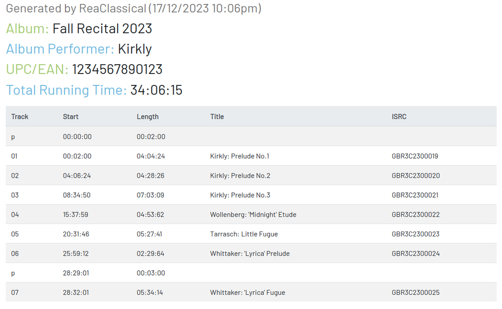

#### BIN+CUE set

Create a BIN/CUE pair (either select `regions define tracks` and render the whole project or select `use only # markers` and render by time selection if you don't want the first pre-gap as actual silence at the start of track 1).

#### Peak and Overs Check

Press `Shift+P` to scan every unmuted track that contains items. The window reports the highest peak level and its position, with a **Go to Peak** button, and lists every point at or above an **over threshold (dB)** that you set, each with a **Go to** button. The scan accounts for item and take volume (including a drawn volume envelope, if SWS is installed) and every fader and send along the routing chain, including RCMASTER and the REAPER master fader. Track volume, pre-FX volume, trim and send volume automation are followed according to each track's automation mode, and muted sends are skipped. Plugins are not included, so it reflects the level reaching the master before effects. Press **Re-scan** after making changes.

Screen reader users (Clara)

`Shift+P` opens an accessible Peak and Overs Check. On opening and on every rescan it announces the peak position and the number of overs and moves the edit cursor to the peak. You can then browse the overs one at a time, hear each over's level, position and track, and audition the peak.

#### Item Peak Check

To check a single take rather than the whole project, select its parent item and press `Tab`. ReaClassical scans that item and the matching items on its child tracks, moves the edit cursor to the highest peak and selects the track it is on. It then reports the peak level, its position and the track, and how far above or below the over threshold it is. The scan takes the same gain into account as the Peak and Overs Check (item and take volume, faders, sends and volume automation through RCMASTER to the master) but not plugins, so the reported level is before effects. The threshold is the one set in the Peak and Overs Check (−1.0 dB by default). SWS is required.

Screen reader users (Clara)

`Tab` announces the result instead of showing a message box.

#### CD Player

Press `Ctrl+Alt+Shift+Y` to play the album back like a physical CD player. The disc is always the first (destination) folder, and only it is heard. The player is a small window that needs keyboard focus, with buttons that mirror its keys for mouse users. When you switch it off with `Escape`, the cursor returns to where it was before you opened the player.

| Key | Action |
| --- | --- |
| `P` | Play, pause or resume |
| `S` | Stop, returning to the start of the disc |
| `→` / `←` | Next track / previous track (restarts the current track if you are more than 3 seconds into it) |
| `↑` / `↓` | Fast forward / rewind |
| `D` | Enter a track number (more than one digit allowed) |
| `1` to `9` | Jump straight to that track |
| `T` | Cycle the time display: track elapsed, track remaining, album elapsed, album remaining |
| `R` | Cycle repeat mode: off, track, album |
| `B` | Toggle **Transition Review** |
| `W` | Set the pre-roll and post-roll for Transition Review |
| `H` | List these keys |
| `Escape` | Power off |

**Transition Review** plays only the joins: the start of the album, every transition between tracks, and the end of the album, each with a pre-roll before and post-roll after (10 seconds and 3 seconds by default). It is the quickest way to hear every splice and gap in a finished album without playing it through. The pregap before track 1 is not included. It reports "Nothing left to review" when it has played the last boundary.

Screen reader users (Clara)

The CD Player works fully from the keyboard and is announced: it says "Reading disc...", the track and time as you move, "Paused" and "Resumed", "No track N" if you ask for a track that does not exist, "Last track" at the end, the review pre- and post-roll values, and "CD Player off" when you close it.

#### Loudness

In terms of loudness, I personally aim for about -18 LUFS Integrated for my classical albums though it can be as high as -16 LUFS and as low as -20 LUFS. The new loudness JSFX meter in REAPER and my own ReaVision Metering Suite along with the normalization of loudness and true-peak limiting in the render dialog are priceless. It's another reason I couldn't go back to the other classical DAWs at this point.

#### Further information on DDP

For more information about DDP metadata see [here](https://reaclassical.com/manual/ddp_info/) (also available via the Render dialog via `Format > DDP` and clicking on `Help`).

- ← Previous
- ↑ Up
- Next →

## Rendering

### Rendering from the DDP Metadata Editor

Rendering is done with the **Render** buttons along the bottom of the DDP Metadata Editor window, which you open with `Y` (Create CD Markers). Each button applies its own settings and renders straight away, without showing REAPER's render dialog. The first (destination) folder is the one rendered, and the files go into an `Exports` subfolder of the project folder.

[figure not shown]

| Button | What it renders | Where it goes |
| --- | --- | --- |
| **DDP** | A DDP image (44.1 kHz, 16-bit, triangular dither, as the Red Book standard requires) | `Exports/DDP/IMAGE.DAT` with its companion files |
| **Cue Audio** | The whole album as one audio file to pair with a CUE file | `Exports/Audio+CUE/` |
| **WAV** | One WAV file per CD track | `Exports/<format>_<samplerate>_<bitdepth>/` |
| **FLAC** | One FLAC file per CD track | `Exports/<format>_<samplerate>_<bitdepth>/` |
| **Opus 160** | One 160 kbps Opus file per CD track (48 kHz) | `Exports/<format>_160/` |
| **MP3 320** | One 320 kbps MP3 file per CD track | `Exports/<format>_320/` |
| **M: Stems** | One WAV per M: mixer track for each CD track, rendered through the master | `Exports/Stems_<format>_<samplerate>_<bitdepth>/` |
| **Custom** | Opens REAPER's render dialog, pre-filled with your choices to the left | wherever you set |

Files for individual CD tracks are named by CD track number and track name. In these per-track files, album and track metadata (titles, performers, ISRC and so on) is embedded where the format supports it, and if the project's media folder contains `cover.jpg` or `cover.png` (or `folder.jpg` or `folder.png`) it is embedded as cover art in MP3, FLAC and Opus files.

Three dropdowns next to the buttons set the **sample rate**, **bit depth** and **dither** for Cue Audio, WAV, FLAC, M: Stems and Custom. DDP always uses the Red Book settings. Opus renders at 48 kHz, and MP3 uses 32, 44.1 or 48 kHz, whichever the chosen sample rate divides into cleanly. The **Tracks** box limits WAV, FLAC, Opus, MP3 and M: Stems to particular CD tracks, for example `1-3,5`; leave it blank to render every track. DDP, Cue Audio and Custom always render the full album.

Before rendering, ReaClassical checks your metadata and warns about text that DDP and CD-Text cannot hold (characters outside Latin-1, embedded line breaks), duplicated ISRC codes and tracks without a title.

Screen reader users (Clara)

The accessible DDP Metadata Editor has a **Render Settings** row (sample rate, bit depth and dither) and a **Render** row where you choose the format and then, if it applies, a track range such as `1-3,5`. Progress and warnings are announced through Clara.

To export every recorded take for the musicians or a producer, see Distributing Takes On Location.

### REAPER's Render Dialog

You can still open REAPER's own render dialog with `R`. In it, click on the presets button then `All Settings`. ReaClassical adds presets for DDP, BIN+CUE, Audio for CUE export, Export for External Resampling, and FLAC, WAV, MP3 and Opus at common sample rates and bit depths. After selecting a preset, you should feel free to change any render settings and perhaps save as a new preset for future use.

### Samplerate

Now that r8brain free has been introduced as the best quality resampler available in REAPER (I highly recommend double-checking that it is selected when resampling at render time) I feel I can do everything, including DDP creation, without leaving my favorite DAW. However, generating a CUE file via the Create CD Markers function is still useful for all sorts of things and I often create FLAC + CUE for album playback in my media player or WAV + CUE to easily burn a CD at home. The **Cue Audio** button renders the whole album as a single file next to its CUE file for exactly this.

### Dither

The Render row offers sample rates of 44.1, 48, 88.2, 96, 176.4 and 192 kHz, bit depths of 16, 24 and 32-bit float, and dither of Triangular, HP filtered, Noise shaping or Off. Dither and noise shaping are applied by the render, so choose **Off** if you prefer to use RCDither or another 3rd-party dither as the last plugin on the master chain. In that case be sure to keep the master fader at unity.

### Loudness & Limiting

REAPER has a fantastic rendering feature which allows the user to set a desired loudness and peak / true peak setting. For quick exports that need to meet certain targets (i.e. streaming) this makes things extremely efficient and is very transparent when not set to extreme values.

### Dry-run Rendering

Another REAPER feature that is outstanding is the dry-run render function which allows for very quick offline loudness and peak checks and much faster than using REAPER's included realtime loudness meter. It is therefore extremely easy to set up compressors, limiters etc in the project and make small adjustments based on the dry-run values and maintain complete control over the process.

### Other Rendering Tips

Not necessarily obvious to new REAPER users are the special =START and =END markers (make your markers in the usual way and label them accordingly) that constrain the length of the project. Rather than rely on extended silence at the end of items or time selections, the =END marker is a great way to ensure you have the exact amount of lead-out you want at the end of the disc. You will hopefully notice I have included various shortcuts for manually creating regions (single or multiple) from items and time selection (great for quickly generating demo snippets). Also worth noting is that you can still do some (or all!) of your source-destination editing with your track markers in place as the S/D markers have IDs far higher than any classical CD would have and are automatically deleted after a successful edit. As long as you have your ripple-per-track mode engaged, all your existing marker placements and carefully crafted edits will remain intact. But, again, don't manually create CD markers at this point as I include a very powerful tool to make light work of that side of mastering.

- ← Previous
- ↑ Up
- Next →

## Collaborating with Video Editors

When working on projects that combine audio and video, the audio engineer must ensure that high-resolution audio edits remain synchronized with the final assembled video. Several approaches exist:

**No audio edits required** – The simplest case. The video editor is free to select camera angles without concerns about audio sync.

**Post-edited audio with playback** – The promotional video is recorded after the audio has been edited, with musicians miming or playing along to playback via loudspeaker. The video editor has complete freedom to cut between angles without sync issues. This method isn't always feasible.

**Minor edits in live-recorded video** – When video and audio are recorded simultaneously and only minor edits are needed, the video editor can use a zoomed-out shot of the concert hall, a musician's face, or another visual to mask a slight time-stretch while preserving timecode accuracy.

**Multiple synchronized takes** – The most complex scenario. Both video and audio are recorded in multiple takes and synchronized via a timeclock. This is the focus of the following discussion.

ReaClassical provides tools to generate an edit list for video editors. Rather than a file for direct import, this list serves as a manual reference. For all recordings, but especially those synchronized to a timeclock, REAPER/ReaClassical retains the timeline start position from the recording. This ensures that absolute in/out source positions can be retrieved even after extensive audio edits. To create an edit list:

1. Perform source-destination edits as usual.
2. Set the desired project framerate in the video tab of Project Settings via `P`.
3. Export the edit list from the ReaClassical menu under Utilities, using the shortcut for the version you need:
   1. **Build Edit List (using BWF Start Offset)** (`Alt+Shift+B`) for timeclock-synced projects. It asks for an optional offset in frames, applied to every time in the list.
   2. **Build Edit List (using source file timing)** (`Ctrl+Shift+B`) to reference positions inside the source audio files. In this case, the audio engineer should provide a single channel of audio to help the video editor locate edit points, and the list also includes the source files used.

The edit list opens in your web browser as an HTML table with a `Done` column for tracking progress. When an offset is used, the page states it in red at the top, so the video editor knows the times have been shifted.

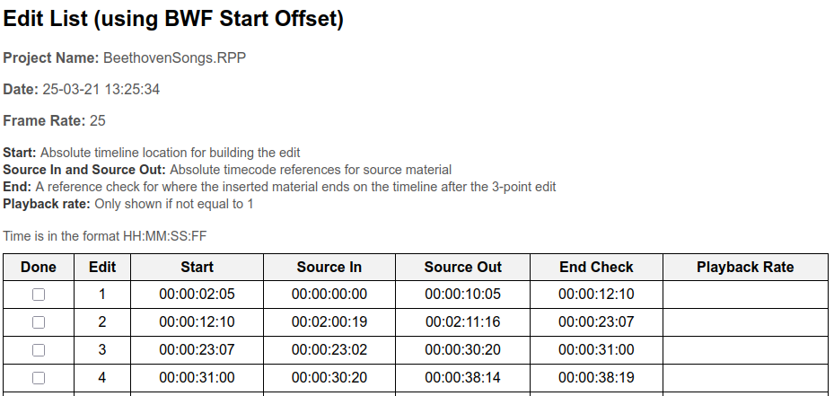

**Take Sheet** combines the edit list (with either timing) with a list of every take recorded, not just the ones used in the edit, so one page can go to the video editor, producer and artists. Each edit row also shows its take number, and if you enabled Global Take Numbers to match globally numbered video files, the sheet shows those too. See Take Sheet.

- ← Previous
- ↑ Up
- Next →

# Getting Help

## This section contains the following topics:

- Frequently Asked Questions
- Community and Support
- ← Previous
- ↑ Up
- Next →

## Frequently Asked Questions

### Do I need my own REAPER license?

ReaClassical installs its own portable copy of REAPER, so there is nothing to download from Cockos first. REAPER itself is separately licensed software: after its evaluation period you should buy a REAPER license from Cockos.

### Can I install ReaClassical into my existing REAPER?

No. The installer creates a separate, self-contained ReaClassical folder with REAPER and everything pre-configured (resource files, theme, keymap and plugins), and installing into an existing setup, including by importing the ReaPack repository on its own, is not supported. See Install.

### What if I only want the source-destination editing functions?

You do not need ReaClassical for that. **ReaEdit** is a free, separate package that adds source-destination editing to regular REAPER, with its own manual at [reaclassical.com/reaedit](https://reaclassical.com/reaedit/). If you use ReaClassical you already have all of these functions, and many more, so you do not need ReaEdit and should not install it.

### Is ReaClassical free?

Yes. ReaClassical and ReaEdit are free and open source, released under the GNU General Public License version 3. There is no license key, no account and no activation. See Licensing.

### How many computers can I use?

As many as you like. There are no seats or machine limits.

### Does ReaClassical work offline?

The installer needs an internet connection. After that ReaClassical works entirely offline: nothing checks a license or contacts a server while you work. You only need the internet again when you ask for a download: **Update ReaClassical**, **Update REAPER**, the Terminal `clara` command, or an update through ReaPack. REAPER's own projects, of course, are ordinary local files.

### Can I carry ReaClassical on a USB drive between computers?

Yes. A ReaClassical folder is portable, so you can copy it to a USB drive and run it on any computer of the same operating system.

### Can my school, university or studio use it on many computers?

Yes, on as many computers as you like.

### What information does ReaClassical send?

None about you or your work. It never uploads your audio or projects. The installer, **Update ReaClassical**, **Update REAPER**, the Terminal `clara` command and ReaPack download files when you ask them to, which is the only network activity. See the [Privacy Policy](https://reaclassical.com/privacy/).

### Which operating systems are supported?

Windows (x64, x86 and ARM64), macOS (Apple silicon, 64-bit Intel and 32-bit Intel) and Linux (x86_64, i686, aarch64 and armv7l, including Raspberry Pi). See Compatibility.

### Can I use my existing REAPER projects?

Yes. Open the project and use **Project Management > Convert REAPER project** in the ReaClassical menu. It converts the project in a new tab, flattens folders, deletes empty tracks and moves effects to the mixer tracks, leaving you to recreate any custom routing in Mission Control. See Converting a Standard REAPER Project.

### Can I open my ReaClassical projects in regular REAPER?

Yes. A ReaClassical project is an ordinary REAPER project: a standard `.RPP` file with your normal audio files, so it opens, plays and renders in any current vanilla REAPER, on any machine, with or without ReaClassical. Your recordings, edits, crossfades, markers and mix are all still there. What regular REAPER does not have is the specialist ReaClassical tooling that makes the work efficient: the recording workflow, source-destination and crossfade editing, Mission Control, mixer snapshots, the mastering tools, the DDP metadata editor and so on. Those exist only in ReaClassical. If the project uses ReaClassical's own plugins (the RCPlugs collection), install them in the other REAPER too, or regular REAPER will show those plugins as missing.

### Should I choose a horizontal or vertical workflow?

Neither is better; each has its advantages. In a horizontal workflow, recorded or imported takes are arranged left to right in a single folder. A vertical workflow helps organize like material in a recording session: takes of the same musical material are recorded vertically aligned, one folder per take. Functions such as finding a take by number work the same way in both, so choose whichever matches how you like to see your session. You can convert between them later in Mission Control. See Project Setup.

### Why can't I rename, add or delete tracks the normal REAPER way?

ReaClassical keeps a set of linked tracks in step with each other (the folders, the M: mixer tracks, aux and submix busses and the routing between them). Doing track management outside Mission Control breaks that link. If you do it by accident, open Mission Control (`C`) and it will recreate what is missing.

### How do I start a recording?

Select the parent track of a folder and press `F9`. This opens the Record Panel and arms the folder. See Recording.

### Where do my recordings go?

Into a `media` subfolder of the project folder by default. You can change the primary and secondary recording paths in REAPER's Project Settings (`P`), on the Media tab.

### How do I give the musicians the takes while I'm still on location?

Press `Ctrl+Shift+D` (**Distribute Takes**, called **Quick Export Recorded Takes** in the ReaClassical menu). It exports all recorded takes, or just the ones you choose, as WAV, FLAC, Opus 160 or MP3 320 into the project's `Exports/Distribute_Takes` folder, using your mixer settings. See Distributing Takes On Location.

### How do I import audio recorded in another DAW?

Name the files with a track name and a take number at the end, such as `cello_012.wav`, put them in the project's media folder and run Smart Import (`Ctrl+Alt+Shift+I`). Multi-channel files from a portable recorder are handled on the Polywav tab. See Importing.

### How do I make a source-destination edit?

Set destination IN and OUT markers with `1` and `2`, source IN and OUT markers with `3` and `4`, and press `5`. Press `F` on the right-hand item of the crossfade to fine-tune it. See Editing.

### How do I undo or repair an edit?

`Ctrl+Z` undoes the last action. To restore the material underneath an earlier S-D edit, select it and press `Ctrl+H` to heal it. If items that should be grouped have become misaligned across the tracks of a folder, for example because ripple-per-track was switched off by accident while dragging items, select any one of them and run **Fix Crossfade Sequence Edits** (`Shift+X`).

### Why do my mixer scenes not sound right in a render?

Mixer snapshots are recalled in real time during playback, which does not work for a faster-than-realtime render. Before rendering, press **Convert to Automation** in the Mixer Snapshot Manager. See Mixing.

### How do I make a DDP image?

Open the DDP Metadata Editor with `Y`, fill in your album and track metadata and click the **DDP** button along the bottom. The result is in the `Exports/DDP` folder of the project. See Mastering and Rendering.

### How do I render each CD track as a separate file?

Use the **WAV**, **FLAC**, **Opus 160** or **MP3 320** buttons in the DDP Metadata Editor. Choose the sample rate, bit depth and dither first, and limit the tracks with the Tracks box if you only need some of them. See Rendering.

### What loudness should I aim for?

That depends on where the music is going. The author aims for about -18 LUFS integrated for classical albums, and anywhere between -20 and -16 LUFS is reasonable. REAPER's render dialog can also normalize to a loudness target and apply true-peak limiting, and a dry run gives you quick loudness and peak values without a full render.

### Can I use my own plugins?

Yes. Any plugin that works in REAPER works in ReaClassical, and Mission Control lets you add FX to the mixer tracks. ReaClassical also comes with a set of mastering-grade JSFX plugins. See Recommended Free Mastering-Grade Plugins.

### Can blind and low-vision engineers use ReaClassical?

Yes. With the Clara accessibility bridge installed, ReaClassical announces what it is doing and provides keyboard-driven windows and modes for every stage of a production. See the Accessibility section.

### How do I update ReaClassical, and how do I reset it?

Press `Shift+U` (Update ReaClassical) to receive the latest version of your major release. A new major version needs a fresh install. To return to the settings from first install, use **ReaClassical Factory Reset** (`Ctrl+Alt+Shift+F`). See Update.

### Is there a PDF manual, and where do I get help?

There is no PDF. The manual is online at https://reaclassical.com/manual and a single-page copy is installed with ReaClassical (press `H`). For support, see Community and Support.

- ← Previous
- ↑ Up
- Next →

## Community and Support

### Support

Support for ReaClassical is provided on the [ReaClassical subforum of the REAPER forum](https://forum.cockos.com/forumdisplay.php?f=57). Please include your operating system, your support info (press `Shift+F1` to copy it, then paste) and, if possible, a description of the steps that led to the problem. Feature requests and bug reports are very welcome there too, or as an issue on [GitHub](https://github.com/chmaha/ReaClassical/issues).

- ← Previous
- ↑ Up
- Next →